# 501 MLR Model

# Multiple Linear Regression Model to Predict Electricity Demand of Five Cities in Spain

## Install all Packages and Import Library

### Packages installation

```r
#Install the required pakages
## Uncomment the installation if the libraries are not currently installed
#install('tidyverse')
#install('dplyr')
#install('car')
#install('GGally')
#install('corrplot')
#install('MASS')
#install('car')
#install('Stat2Data')
#install('olsrr')
#install('leaps')
#install('caret')
#install('leaps')
#install('lmtest')
#install('nortest')
#install(broom.mixed)
```

### Import library

```r
library(tidyverse)
library(dplyr)
library(car)
library (GGally)
library(corrplot)
library(MASS)
library(car)
library(Stat2Data)
library(olsrr)
library(leaps)
library(rgl)
library(leaps)
library(caret)
library(lmtest)
library(nortest)
library(Metrics)
library(broom.mixed)
options(scipen=999)  # turn-off scientific notation like 1e+48
theme_set(theme_bw())  # pre-set the bw theme.
```

## Barcelona Model

### Data Processing

#### Read working and evaluation data set, moreover, remove the index and time stamp and snow_duration variable since it is invalid variable

```r
evaldata<-read.csv('data\\evaluation_Barcelona.csv')
workdata<-read.csv('data\\working_Barcelona.csv')
#remove index, time_ID and snow_duration columns from "eval" analysis dataframe
evalBarcelona<-evaldata[c(-1,-2,-11)]
#remove index, time_ID and snow_duration columns from "work" analysis dataframe
workBarcelona<-workdata[c(-1,-2,-11)]
head(workBarcelona, 4L)
```

|  | E_1 | E_2 | E_25 | temp | humidity | pressure | wind_speed | rain_duration | day_night | time_band | season | weather_main | energy_demand |
| --- | --- | --- | --- | --- | --- | --- | --- | --- | --- | --- | --- | --- | --- |
| 1 | 2949.490 | 2750.131 | 3274.657 | 281.625 | 100 | 1035 | 7 | 0 | 2 | 1 | 4 | 1 | 3070.822 |
| 2 | 2574.967 | 2451.335 | 2808.197 | 281.286 | 100 | 1036 | 7 | 0 | 2 | 1 | 4 | 1 | 2750.131 |
| 3 | 2451.335 | 2407.907 | 2726.663 | 281.286 | 100 | 1036 | 7 | 0 | 2 | 1 | 4 | 1 | 2574.967 |
| 4 | 2407.907 | 2420.609 | 2672.952 | 281.286 | 100 | 1036 | 7 | 0 | 2 | 1 | 4 | 1 | 2451.335 |

### Create the ggpair plot and Correlation plot

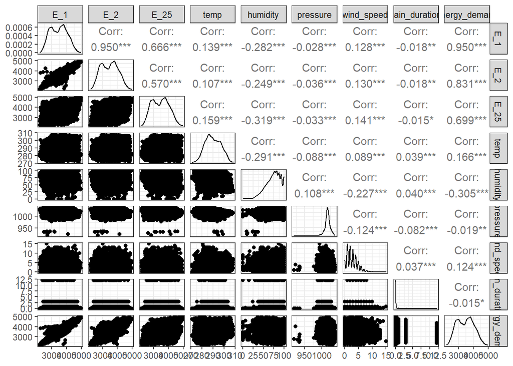

```r
# Correlation matrix for numeric predictors only (categorical predictors excluded)
workcor<-workBarcelona[c(-9:-12) ]
ggpairs(workcor)
```

```r
cor(workBarcelona)
```

```
##                       E_1         E_2        E_25        temp    humidity
## E_1            1.00000000  0.95043237  0.66580794  0.13878927 -0.28177561
## E_2            0.95043237  1.00000000  0.56952817  0.10748859 -0.24873502
## E_25           0.66580794  0.56952817  1.00000000  0.15876073 -0.31888324
## temp           0.13878927  0.10748859  0.15876073  1.00000000 -0.29083714
## humidity      -0.28177561 -0.24873502 -0.31888324 -0.29083714  1.00000000
## pressure      -0.02781520 -0.03648859 -0.03315805 -0.08811130  0.10761304
## wind_speed     0.12785107  0.12975971  0.14094675  0.08937600 -0.22672868
## rain_duration -0.01756328 -0.01762592 -0.01457261  0.03851107  0.04008084
## day_night     -0.54619626 -0.53930978 -0.50875513 -0.31948333  0.36984305
## time_band      0.11196718  0.09187944  0.11252593 -0.10385953 -0.09771753
## season         0.08088787  0.07961938  0.08003023 -0.34479411  0.04568793
## weather_main  -0.01894161 -0.01580890 -0.01977277 -0.03246087  0.18608532
## energy_demand  0.95024655  0.83107411  0.69947826  0.16573813 -0.30543266
##                  pressure  wind_speed rain_duration    day_night    time_band
## E_1           -0.02781520  0.12785107   -0.01756328 -0.546196259  0.111967183
## E_2           -0.03648859  0.12975971   -0.01762592 -0.539309783  0.091879443
## E_25          -0.03315805  0.14094675   -0.01457261 -0.508755131  0.112525926
## temp          -0.08811130  0.08937600    0.03851107 -0.319483326 -0.103859527
## humidity       0.10761304 -0.22672868    0.04008084  0.369843046 -0.097717527
## pressure       1.00000000 -0.12403082   -0.08243537  0.042578653 -0.030693135
## wind_speed    -0.12403082  1.00000000    0.03733744 -0.237455373 -0.000365960
## rain_duration -0.08243537  0.03733744    1.00000000 -0.013813870  0.024856915
## day_night      0.04257865 -0.23745537   -0.01381387  1.000000000  0.001813599
## time_band     -0.03069313 -0.00036596    0.02485691  0.001813599  1.000000000
## season         0.22132029 -0.02069053   -0.03184723  0.150789145  0.163635620
## weather_main  -0.18441348  0.05154379    0.43511910  0.007496362 -0.012094920
## energy_demand -0.01938825  0.12361053   -0.01523665 -0.512051575  0.123752931
##                    season weather_main energy_demand
## E_1            0.08088787 -0.018941608    0.95024655
## E_2            0.07961938 -0.015808902    0.83107411
## E_25           0.08003023 -0.019772771    0.69947826
## temp          -0.34479411 -0.032460871    0.16573813
## humidity       0.04568793  0.186085318   -0.30543266
## pressure       0.22132029 -0.184413485   -0.01938825
## wind_speed    -0.02069053  0.051543786    0.12361053
## rain_duration -0.03184723  0.435119102   -0.01523665
## day_night      0.15078914  0.007496362   -0.51205158
## time_band      0.16363562 -0.012094920    0.12375293
## season         1.00000000 -0.015869470    0.08143799
## weather_main  -0.01586947  1.000000000   -0.02147315
## energy_demand  0.08143799 -0.021473153    1.00000000
```

### Create color spectrum correlation plot

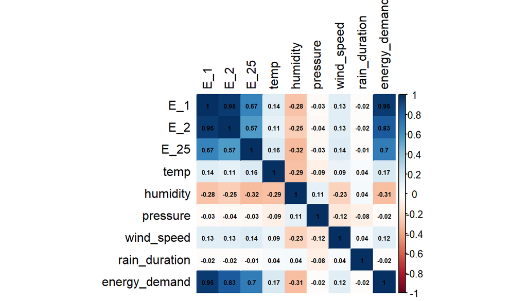

```r
corrplot(cor(workcor), method="color", type="full", addCoef.col = "black", tl.col="black",number.cex = 0.5)
```

## Model Processing

### Build the full model

```r
workModel1 <- lm(energy_demand ~ E_1 + E_2 + E_25 + temp + humidity + pressure + wind_speed + rain_duration + factor(day_night) + factor(time_band) + factor(season) + factor(weather_main), data = workBarcelona)
```

### Check the multicollinearity assumption

```r
vif(workModel1)
```

```
##                           GVIF Df GVIF^(1/(2*Df))
## E_1                  13.942127  1        3.733916
## E_2                  11.846657  1        3.441897
## E_25                  2.148160  1        1.465660
## temp                  3.375736  1        1.837318
## humidity              1.444593  1        1.201912
## pressure              1.163925  1        1.078854
## wind_speed            1.140701  1        1.068036
## rain_duration         1.350867  1        1.162268
## factor(day_night)     1.913604  1        1.383331
## factor(time_band)     1.102038  2        1.024588
## factor(season)        3.546552  3        1.234907
## factor(weather_main)  1.581208  8        1.029051
```

According to the VIF output E_1 and E_2 variables have serious multicollinearity issue thus remove E_2 and rebuild the model.

### Dropping only E_2, not both E_1 and E_2, to address multicollinearity between E_1 and E_2

```r
workModelFull <- lm(energy_demand ~ E_1 + E_25 + temp + humidity + pressure + wind_speed + rain_duration + factor(day_night) + factor(time_band) + factor(season) + factor(weather_main), data = workBarcelona)
vif(workModelFull)
```

```
##                          GVIF Df GVIF^(1/(2*Df))
## E_1                  2.049752  1        1.431696
## E_25                 1.962199  1        1.400785
## temp                 3.305833  1        1.818195
## humidity             1.444100  1        1.201707
## pressure             1.161911  1        1.077920
## wind_speed           1.139121  1        1.067296
## rain_duration        1.350681  1        1.162188
## factor(day_night)    1.849385  1        1.359921
## factor(time_band)    1.098891  2        1.023855
## factor(season)       3.487460  3        1.231454
## factor(weather_main) 1.580054  8        1.029004
```

According to the VIF output, we can observe that there’s no serious multicollinearity issue.

### Model assumption check

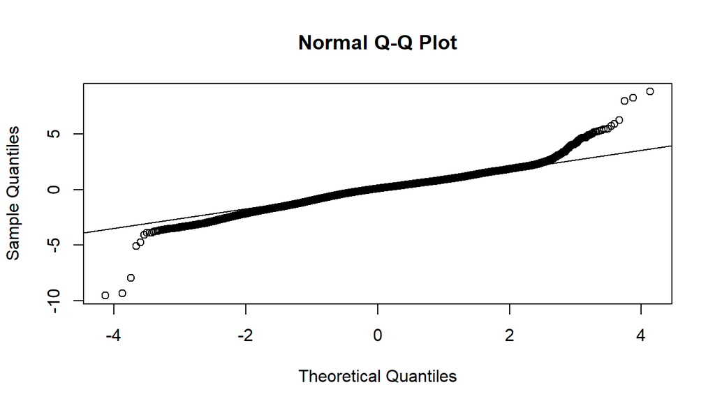

```r
# to obtain residuals
res.fullmodel1 <- residuals(workModelFull)
# to obtain standardized residuals
std.res.fullmodel1 <- rstandard(workModelFull)
# to obtain fitted/predicted values
pred.fullmodel1 <- fitted.values(workModelFull)
par(mfrow=c(1,1))
qqnorm(y = std.res.fullmodel1, main = " Normal Q-Q Plot ",
       xlab = "Theoretical Quantiles", ylab = "Sample Quantiles")
qqline(y = std.res.fullmodel1)
```

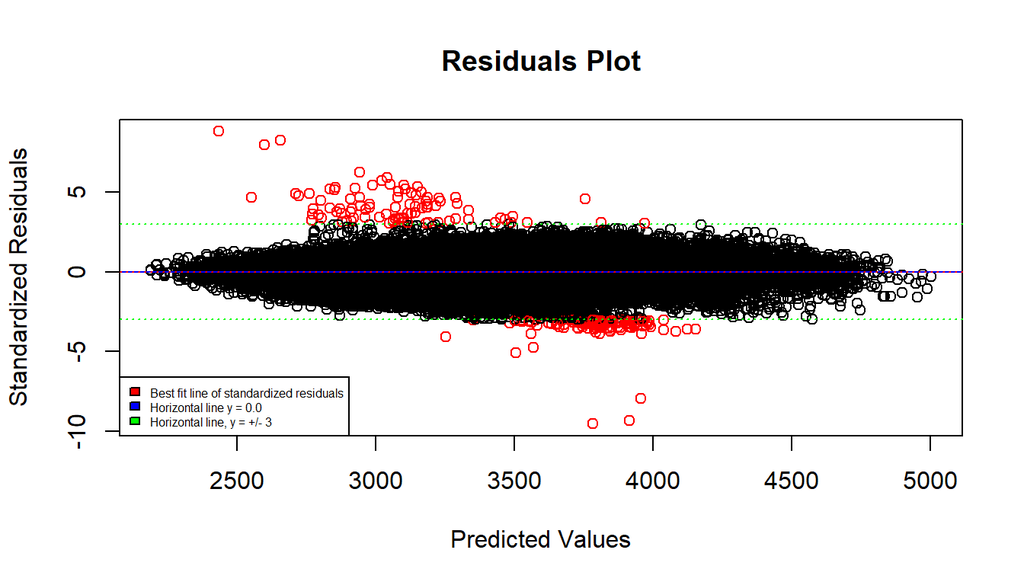

```r
resplotdata1 <- data.frame(std.res.fullmodel1, pred.fullmodel1)
resbf1 <- lm(std.res.fullmodel1 ~ pred.fullmodel1, data = resplotdata1)
plot(x = pred.fullmodel1, y = std.res.fullmodel1, ylab = "Standardized Residuals", xlab = "Predicted Values", main = "Residuals Plot", col = ifelse(std.res.fullmodel1 < -3,"red",ifelse(std.res.fullmodel1 > 3,"red","black")))
abline(h = 0, col="blue", lty=1)
abline(resbf1, col="red", lty=3)
abline(h = 3, col="green", lty=3)
abline(h=-3, col="green", lty=3)
legend("bottomleft", legend=c("Best fit line of standardized residuals", "Horizontal line y = 0.0", "Horizontal line, y = +/- 3"), fill = c("red","blue","green"), cex = 0.5)
```

According to the residual plot, we can observe that there’s no heteroscedasticity issue , nevertheless, there are several outliers.

### Check the regression output and build the reduce model

#### Based on regression summary, predictor *rain_duration* dropped as insignificant (p-values is > 0.05). Build a reduce model then compare with the full model

```r
summary(workModelFull)
```

```
##
## Call:
## lm(formula = energy_demand ~ E_1 + E_25 + temp + humidity + pressure +
##     wind_speed + rain_duration + factor(day_night) + factor(time_band) +
##     factor(season) + factor(weather_main), data = workBarcelona)
##
## Residuals:
##      Min       1Q   Median       3Q      Max
## -1531.74   -90.57    14.60    99.89  1412.55
##
## Coefficients:
##                            Estimate   Std. Error t value             Pr(>|t|)
## (Intercept)            -2803.519570   152.435690 -18.391 < 0.0000000000000002
## E_1                        0.885257     0.002489 355.738 < 0.0000000000000002
## E_25                       0.121752     0.002432  50.067 < 0.0000000000000002
## temp                       7.170224     0.260203  27.556 < 0.0000000000000002
## humidity                  -0.634227     0.065866  -9.629 < 0.0000000000000002
## pressure                   0.730545     0.136673   5.345       0.000000091017
## wind_speed                -1.977760     0.514097  -3.847              0.00012
## rain_duration              2.422471     1.711138   1.416              0.15687
## factor(day_night)2        65.503160     2.613422  25.064 < 0.0000000000000002
## factor(time_band)2       -18.244439    12.868697  -1.418              0.15628
## factor(time_band)3        62.331534    10.004587   6.230       0.000000000472
## factor(season)2          -73.426137     3.686941 -19.915 < 0.0000000000000002
## factor(season)3          -29.983347     2.900109 -10.339 < 0.0000000000000002
## factor(season)4           17.277737     3.165117   5.459       0.000000048344
## factor(weather_main)2     -2.322696     2.122710  -1.094              0.27387
## factor(weather_main)3    -13.355521    13.517978  -0.988              0.32317
## factor(weather_main)4    156.628292   113.610051   1.379              0.16801
## factor(weather_main)5     16.796013    22.805446   0.736              0.46144
## factor(weather_main)7    -43.788142     9.722793  -4.504       0.000006706350
## factor(weather_main)8     13.107792     4.065549   3.224              0.00127
## factor(weather_main)10   117.912863    48.565247   2.428              0.01519
## factor(weather_main)12     3.124515    12.573762   0.248              0.80375
##
## (Intercept)            ***
## E_1                    ***
## E_25                   ***
## temp                   ***
## humidity               ***
```

[output cut: 8 more lines]

```
## factor(season)4        ***
## factor(weather_main)2
## factor(weather_main)3
## factor(weather_main)4
## factor(weather_main)5
## factor(weather_main)7  ***
## factor(weather_main)8  **
## factor(weather_main)10 *
## factor(weather_main)12
## ---
## Signif. codes:  0 '***' 0.001 '**' 0.01 '*' 0.05 '.' 0.1 ' ' 1
##
## Residual standard error: 160.6 on 27940 degrees of freedom
## Multiple R-squared:  0.9156, Adjusted R-squared:  0.9156
## F-statistic: 1.444e+04 on 21 and 27940 DF,  p-value: < 0.00000000000000022
```

```r
df<- workModelFull %>%
  tidy()
#Get the variables which there p-value larger than 0.05
df%>%
  filter(df$p.value>0.05)
```

| term | estimate | std.error | statistic | p.value |
| --- | --- | --- | --- | --- |
| rain_duration | 2.422471 | 1.711138 | 1.4157081 | 0.1568721 |
| factor(time_band)2 | -18.244439 | 12.868697 | -1.4177379 | 0.1562785 |
| factor(weather_main)2 | -2.322696 | 2.122710 | -1.0942123 | 0.2738713 |
| factor(weather_main)3 | -13.355521 | 13.517978 | -0.9879822 | 0.3231699 |
| factor(weather_main)4 | 156.628292 | 113.610051 | 1.3786482 | 0.1680143 |
| factor(weather_main)5 | 16.796013 | 22.805446 | 0.7364913 | 0.4614379 |
| factor(weather_main)12 | 3.124515 | 12.573762 | 0.2484948 | 0.8037534 |

```r
workModelPvalue <- lm(energy_demand ~ E_1 + E_25 + temp + humidity + pressure + wind_speed + factor(day_night) + factor(time_band) + factor(season) + factor(weather_main), data = workBarcelona)
summary(workModelPvalue)
```

```
##
## Call:
## lm(formula = energy_demand ~ E_1 + E_25 + temp + humidity + pressure +
##     wind_speed + factor(day_night) + factor(time_band) + factor(season) +
##     factor(weather_main), data = workBarcelona)
##
## Residuals:
##      Min       1Q   Median       3Q      Max
## -1532.03   -90.58    14.64    99.91  1412.13
##
## Coefficients:
##                            Estimate   Std. Error t value             Pr(>|t|)
## (Intercept)            -2804.180567   152.437714 -18.396 < 0.0000000000000002
## E_1                        0.885189     0.002488 355.770 < 0.0000000000000002
## E_25                       0.121702     0.002432  50.051 < 0.0000000000000002
## temp                       7.162242     0.260147  27.532 < 0.0000000000000002
## humidity                  -0.638104     0.065810  -9.696 < 0.0000000000000002
## pressure                   0.734014     0.136653   5.371       0.000000078767
## wind_speed                -1.962770     0.513997  -3.819             0.000134
## factor(day_night)2        65.425220     2.612889  25.039 < 0.0000000000000002
## factor(time_band)2       -17.154791    12.845890  -1.335             0.181746
## factor(time_band)3        62.623435    10.002642   6.261       0.000000000389
## factor(season)2          -72.999238     3.674655 -19.866 < 0.0000000000000002
## factor(season)3          -29.911221     2.899713 -10.315 < 0.0000000000000002
## factor(season)4           17.237276     3.165045   5.446       0.000000051908
## factor(weather_main)2     -2.311979     2.122735  -1.089             0.276097
## factor(weather_main)3    -13.139596    13.517361  -0.972             0.331032
## factor(weather_main)4    156.902134   113.611928   1.381             0.167279
## factor(weather_main)5     16.929897    22.805659   0.742             0.457878
## factor(weather_main)7    -43.540310     9.721391  -4.479       0.000007535584
## factor(weather_main)8     15.811254     3.589221   4.405       0.000010607663
## factor(weather_main)10   118.504216    48.564323   2.440             0.014687
## factor(weather_main)12     3.569918    12.570052   0.284             0.776411
##
## (Intercept)            ***
## E_1                    ***
## E_25                   ***
## temp                   ***
## humidity               ***
## pressure               ***
## wind_speed             ***
## factor(day_night)2     ***
## factor(time_band)2
## factor(time_band)3     ***
## factor(season)2        ***
## factor(season)3        ***
## factor(season)4        ***
## factor(weather_main)2
## factor(weather_main)3
## factor(weather_main)4
## factor(weather_main)5
## factor(weather_main)7  ***
## factor(weather_main)8  ***
## factor(weather_main)10 *
## factor(weather_main)12
## ---
## Signif. codes:  0 '***' 0.001 '**' 0.01 '*' 0.05 '.' 0.1 ' ' 1
##
## Residual standard error: 160.6 on 27941 degrees of freedom
## Multiple R-squared:  0.9156, Adjusted R-squared:  0.9156
## F-statistic: 1.516e+04 on 20 and 27941 DF,  p-value: < 0.00000000000000022
```

### Reduced model comparisons

- p-value approach

```r
anova(workModelPvalue, workModelFull)
```

|  | Res.Df | RSS | Df | Sum of Sq | F | Pr(>F) |
| --- | --- | --- | --- | --- | --- | --- |
| 1 | 27941 | 720280919 | NA | NA | NA | NA |
| 2 | 27940 | 720229254 | 1 | 51664.45 | 2.004229 | 0.1568721 |

At 5% significance level , no statistical evidence to support that the full model is preferred over than reduced model.(it’s simpler… no prediction performance is lost via the elimination of identified predictors). That is to say, workModelPvalue is preferred over workModelFull.

- Best subset selection method

### Based on the the Best subset selection method, we drop pressue, wind_speed, rain_duration, time_band and weather_main to build the reduce model.

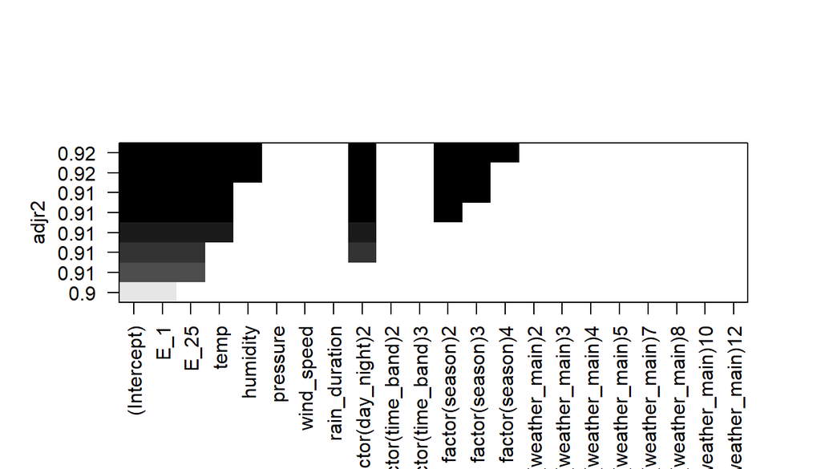

```r
bestfits <- regsubsets(energy_demand ~ E_1 + E_25 + temp + humidity + pressure + wind_speed + rain_duration + factor(day_night) + factor(time_band) + factor(season) + factor(weather_main), data = workBarcelona, nbest = 1)
plot(bestfits, scale="adjr2")
```

```r
workModelBestfit<-lm(energy_demand ~ E_1 + E_25 + temp + humidity + factor(day_night) + factor(season) , data = workBarcelona)
summary(workModelBestfit)
```

```
##
## Call:
## lm(formula = energy_demand ~ E_1 + E_25 + temp + humidity + factor(day_night) +
##     factor(season), data = workBarcelona)
##
## Residuals:
##      Min       1Q   Median       3Q      Max
## -1543.34   -90.26    15.10    99.63  1400.13
##
## Coefficients:
##                        Estimate   Std. Error t value             Pr(>|t|)
## (Intercept)        -2052.560979    76.260658 -26.915 < 0.0000000000000002 ***
## E_1                    0.885823     0.002487 356.180 < 0.0000000000000002 ***
## E_25                   0.122668     0.002431  50.459 < 0.0000000000000002 ***
## temp                   7.080417     0.257109  27.539 < 0.0000000000000002 ***
## humidity              -0.566084     0.063212  -8.955 < 0.0000000000000002 ***
## factor(day_night)2    67.594434     2.564110  26.362 < 0.0000000000000002 ***
## factor(season)2      -70.964302     3.649244 -19.446 < 0.0000000000000002 ***
## factor(season)3      -27.809163     2.884814  -9.640 < 0.0000000000000002 ***
## factor(season)4       21.157266     3.034653   6.972      0.0000000000032 ***
## ---
## Signif. codes:  0 '***' 0.001 '**' 0.01 '*' 0.05 '.' 0.1 ' ' 1
##
## Residual standard error: 160.9 on 27953 degrees of freedom
## Multiple R-squared:  0.9152, Adjusted R-squared:  0.9152
## F-statistic: 3.77e+04 on 8 and 27953 DF,  p-value: < 0.00000000000000022
```

```r
anova(workModelBestfit, workModelPvalue)
```

|  | Res.Df | RSS | Df | Sum of Sq | F | Pr(>F) |
| --- | --- | --- | --- | --- | --- | --- |
| 1 | 27953 | 723907059 | NA | NA | NA | NA |
| 2 | 27941 | 720280919 | 12 | 3626141 | 11.72205 | 0.000000000000000000000005121485 |

At 5% significance level , no statistical evidence to support that the Bestfit model is preferred over than Pvalue model.(it’s simpler… no prediction performance is lost via the elimination of identified predictors). That is to say, workModelPvalue is preferred over workModelBestfit.

- AIC with forward selection approach test method

### According to the AIC method output, we get the same multiple linear model as full model.

```r
workNullModel <- lm(energy_demand ~ 1, data = workBarcelona)
step.working <- stepAIC(workNullModel, scope = list(lower = workNullModel,
upper = workModelFull), direction = "forward", trace=FALSE)
summary(step.working)
```

```
##
## Call:
## lm(formula = energy_demand ~ E_1 + E_25 + factor(day_night) +
##     temp + factor(season) + humidity + factor(time_band) + factor(weather_main) +
##     pressure + wind_speed + rain_duration, data = workBarcelona)
##
## Residuals:
##      Min       1Q   Median       3Q      Max
## -1531.74   -90.57    14.60    99.89  1412.55
##
## Coefficients:
##                            Estimate   Std. Error t value             Pr(>|t|)
## (Intercept)            -2803.519570   152.435690 -18.391 < 0.0000000000000002
## E_1                        0.885257     0.002489 355.738 < 0.0000000000000002
## E_25                       0.121752     0.002432  50.067 < 0.0000000000000002
## factor(day_night)2        65.503160     2.613422  25.064 < 0.0000000000000002
## temp                       7.170224     0.260203  27.556 < 0.0000000000000002
## factor(season)2          -73.426137     3.686941 -19.915 < 0.0000000000000002
## factor(season)3          -29.983347     2.900109 -10.339 < 0.0000000000000002
## factor(season)4           17.277737     3.165117   5.459       0.000000048344
## humidity                  -0.634227     0.065866  -9.629 < 0.0000000000000002
## factor(time_band)2       -18.244439    12.868697  -1.418              0.15628
## factor(time_band)3        62.331534    10.004587   6.230       0.000000000472
## factor(weather_main)2     -2.322696     2.122710  -1.094              0.27387
## factor(weather_main)3    -13.355521    13.517978  -0.988              0.32317
## factor(weather_main)4    156.628292   113.610051   1.379              0.16801
## factor(weather_main)5     16.796013    22.805446   0.736              0.46144
## factor(weather_main)7    -43.788142     9.722793  -4.504       0.000006706350
## factor(weather_main)8     13.107792     4.065549   3.224              0.00127
## factor(weather_main)10   117.912863    48.565247   2.428              0.01519
## factor(weather_main)12     3.124515    12.573762   0.248              0.80375
## pressure                   0.730545     0.136673   5.345       0.000000091017
## wind_speed                -1.977760     0.514097  -3.847              0.00012
## rain_duration              2.422471     1.711138   1.416              0.15687
##
## (Intercept)            ***
## E_1                    ***
## E_25                   ***
## factor(day_night)2     ***
## temp                   ***
```

[output cut: 8 more lines]

```
## factor(weather_main)4
## factor(weather_main)5
## factor(weather_main)7  ***
## factor(weather_main)8  **
## factor(weather_main)10 *
## factor(weather_main)12
## pressure               ***
## wind_speed             ***
## rain_duration
## ---
## Signif. codes:  0 '***' 0.001 '**' 0.01 '*' 0.05 '.' 0.1 ' ' 1
##
## Residual standard error: 160.6 on 27940 degrees of freedom
## Multiple R-squared:  0.9156, Adjusted R-squared:  0.9156
## F-statistic: 1.444e+04 on 21 and 27940 DF,  p-value: < 0.00000000000000022
```

- Cross Validation test method

```r
# Set seed for reproducibility in CV
set.seed(123)
# Set up repeated k-fold cross-validation, with k=10
train.control <- trainControl(method = "cv", number = 10)
# Train the model
step.cv.work <- train(energy_demand ~ E_1 + E_25 + temp + humidity + pressure + wind_speed + rain_duration + factor(day_night) + factor(time_band) + factor(season) + factor(weather_main), data = workBarcelona, method = "leapBackward",
tuneGrid = data.frame(nvmax = 1:11),
trControl = train.control)
step.cv.work$results
```

|  | nvmax | RMSE | Rsquared | MAE | RMSESD | RsquaredSD | MAESD |
| --- | --- | --- | --- | --- | --- | --- | --- |
| 1 | 1 | 172.1011 | 0.9029943 | 128.5505 | 1.646633 | 0.001598235 | 1.474566 |
| 2 | 2 | 164.8482 | 0.9109956 | 125.7942 | 1.834727 | 0.002174917 | 1.637397 |
| 3 | 3 | 164.0189 | 0.9118859 | 125.3700 | 1.942731 | 0.002195736 | 1.666391 |
| 4 | 4 | 162.8075 | 0.9131825 | 124.3157 | 1.813539 | 0.002112150 | 1.699576 |
| 5 | 5 | 162.0026 | 0.9140349 | 123.4603 | 1.962722 | 0.002212135 | 1.846831 |
| 6 | 6 | 161.3498 | 0.9147255 | 122.8227 | 1.972584 | 0.002257363 | 1.881204 |
| 7 | 7 | 161.0719 | 0.9150180 | 122.4441 | 1.927744 | 0.002208508 | 1.844566 |
| 8 | 8 | 161.0404 | 0.9150532 | 122.3919 | 1.939698 | 0.002233429 | 1.864814 |
| 9 | 9 | 160.8549 | 0.9152489 | 122.2854 | 1.877264 | 0.002187875 | 1.855482 |
| 10 | 10 | 160.8581 | 0.9152448 | 122.2658 | 1.976584 | 0.002267899 | 1.908185 |

[output cut: 1 more lines]

```r
summary(step.cv.work$finalModel)
```

```
## Subset selection object
## 21 Variables  (and intercept)
##                        Forced in Forced out
## E_1                        FALSE      FALSE
## E_25                       FALSE      FALSE
## temp                       FALSE      FALSE
## humidity                   FALSE      FALSE
## pressure                   FALSE      FALSE
## wind_speed                 FALSE      FALSE
## rain_duration              FALSE      FALSE
## factor(day_night)2         FALSE      FALSE
## factor(time_band)2         FALSE      FALSE
## factor(time_band)3         FALSE      FALSE
## factor(season)2            FALSE      FALSE
## factor(season)3            FALSE      FALSE
## factor(season)4            FALSE      FALSE
## factor(weather_main)2      FALSE      FALSE
## factor(weather_main)3      FALSE      FALSE
## factor(weather_main)4      FALSE      FALSE
## factor(weather_main)5      FALSE      FALSE
## factor(weather_main)7      FALSE      FALSE
## factor(weather_main)8      FALSE      FALSE
## factor(weather_main)10     FALSE      FALSE
## factor(weather_main)12     FALSE      FALSE
## 1 subsets of each size up to 11
## Selection Algorithm: backward
##           E_1 E_25 temp humidity pressure wind_speed rain_duration
## 1  ( 1 )  "*" " "  " "  " "      " "      " "        " "
## 2  ( 1 )  "*" "*"  " "  " "      " "      " "        " "
## 3  ( 1 )  "*" "*"  " "  " "      " "      " "        " "
## 4  ( 1 )  "*" "*"  "*"  " "      " "      " "        " "
## 5  ( 1 )  "*" "*"  "*"  " "      " "      " "        " "
## 6  ( 1 )  "*" "*"  "*"  " "      " "      " "        " "
## 7  ( 1 )  "*" "*"  "*"  "*"      " "      " "        " "
## 8  ( 1 )  "*" "*"  "*"  "*"      " "      " "        " "
## 9  ( 1 )  "*" "*"  "*"  "*"      "*"      " "        " "
## 10  ( 1 ) "*" "*"  "*"  "*"      "*"      " "        " "
## 11  ( 1 ) "*" "*"  "*"  "*"      "*"      " "        " "
##           factor(day_night)2 factor(time_band)2 factor(time_band)3
## 1  ( 1 )  " "                " "                " "
```

[output cut: 43 more lines]

```
## 9  ( 1 )  " "                   " "                   " "
## 10  ( 1 ) " "                   "*"                   " "
## 11  ( 1 ) " "                   "*"                   " "
##           factor(weather_main)12
## 1  ( 1 )  " "
## 2  ( 1 )  " "
## 3  ( 1 )  " "
## 4  ( 1 )  " "
## 5  ( 1 )  " "
## 6  ( 1 )  " "
## 7  ( 1 )  " "
## 8  ( 1 )  " "
## 9  ( 1 )  " "
## 10  ( 1 ) " "
## 11  ( 1 ) " "
```

```r
workModelCross <- lm(energy_demand ~ E_1 + E_25 + temp + humidity + pressure + factor(day_night) + factor(time_band) + factor(season) + factor(weather_main), data = workBarcelona)
anova( workModelCross, workModelPvalue)
```

|  | Res.Df | RSS | Df | Sum of Sq | F | Pr(>F) |
| --- | --- | --- | --- | --- | --- | --- |
| 1 | 27942 | 720656824 | NA | NA | NA | NA |
| 2 | 27941 | 720280919 | 1 | 375904.7 | 14.58202 | 0.0001344782 |

```r
summary(workModelCross)
```

```
##
## Call:
## lm(formula = energy_demand ~ E_1 + E_25 + temp + humidity + pressure +
##     factor(day_night) + factor(time_band) + factor(season) +
##     factor(weather_main), data = workBarcelona)
##
## Residuals:
##      Min       1Q   Median       3Q      Max
## -1539.30   -90.57    14.51    99.82  1403.40
##
## Coefficients:
##                            Estimate   Std. Error t value             Pr(>|t|)
## (Intercept)            -2842.315313   152.147211 -18.681 < 0.0000000000000002
## E_1                        0.885397     0.002488 355.852 < 0.0000000000000002
## E_25                       0.121666     0.002432  50.024 < 0.0000000000000002
## temp                       7.085295     0.259428  27.311 < 0.0000000000000002
## humidity                  -0.607712     0.065343  -9.300 < 0.0000000000000002
## pressure                   0.784867     0.136036   5.770       0.000000008032
## factor(day_night)2        66.722012     2.591356  25.748 < 0.0000000000000002
## factor(time_band)2       -15.310566    12.839927  -1.192               0.2331
## factor(time_band)3        63.568928    10.002007   6.356       0.000000000211
## factor(season)2          -71.764888     3.661300 -19.601 < 0.0000000000000002
## factor(season)3          -29.174014     2.893983 -10.081 < 0.0000000000000002
## factor(season)4           16.333074     3.156942   5.174       0.000000231086
## factor(weather_main)2     -3.183514     2.110943  -1.508               0.1315
## factor(weather_main)3    -13.335646    13.520548  -0.986               0.3240
## factor(weather_main)4    151.166860   113.629607   1.330               0.1834
## factor(weather_main)5     15.960942    22.809789   0.700               0.4841
## factor(weather_main)7    -43.087845     9.723032  -4.432       0.000009392517
## factor(weather_main)8     14.635296     3.576855   4.092       0.000042948541
## factor(weather_main)10   120.377548    48.573646   2.478               0.0132
## factor(weather_main)12     2.616717    12.570627   0.208               0.8351
##
## (Intercept)            ***
## E_1                    ***
## E_25                   ***
## temp                   ***
## humidity               ***
## pressure               ***
## factor(day_night)2     ***
## factor(time_band)2
## factor(time_band)3     ***
## factor(season)2        ***
## factor(season)3        ***
## factor(season)4        ***
## factor(weather_main)2
## factor(weather_main)3
## factor(weather_main)4
## factor(weather_main)5
## factor(weather_main)7  ***
## factor(weather_main)8  ***
## factor(weather_main)10 *
## factor(weather_main)12
## ---
## Signif. codes:  0 '***' 0.001 '**' 0.01 '*' 0.05 '.' 0.1 ' ' 1
##
## Residual standard error: 160.6 on 27942 degrees of freedom
## Multiple R-squared:  0.9156, Adjusted R-squared:  0.9155
## F-statistic: 1.595e+04 on 19 and 27942 DF,  p-value: < 0.00000000000000022
```

At 5% significance level , no statistical evidence to support that the Cross Validation model is preferred over than Pvalue model.(it’s simpler… no prediction performance is lost via the elimination of identified predictors). That is to say, workModelPvalue is preferred over workModelCross

## Select the final model

Model adjusted R-square from above methods

1. P-value: 0.9156
2. Bestfits: 0.9152
3. AIC Method: 0.9156
4. Cross-validation: 0.9155

Final model is the workModelPvalue with highest Adjusted R-square.

### Build the Final Model

```r
workFinal <- lm(energy_demand ~ E_1 + E_25 + factor(day_night) + temp + factor(season) + humidity + factor(time_band) + factor(weather_main) + pressure + wind_speed, data = workBarcelona)
```

### Check the linearity, heteroscedasticity, outlier and normal assumption

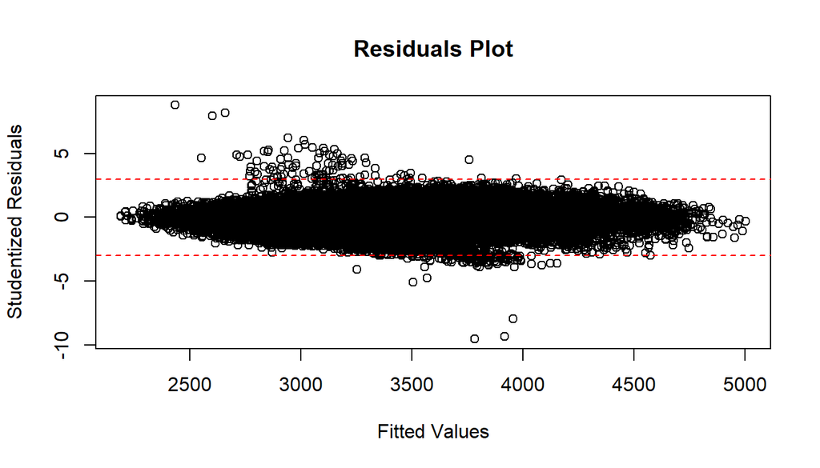

```r
par(mfrow=c(1,1))
#Residual Plot
plot(x=fitted(workFinal), y=studres(workFinal), xlab = "Fitted Values",
ylab = "Studentized Residuals", main='Residuals Plot')
abline(h=-3, col="red", lty=2)
abline(h=3, col="red", lty=2)
```

```r
#norm test
std.res <- rstandard(workFinal)
ad.test(std.res)
```

```
##
##  Anderson-Darling normality test
##
## data:  std.res
## A = 122.77, p-value < 0.00000000000000022
```

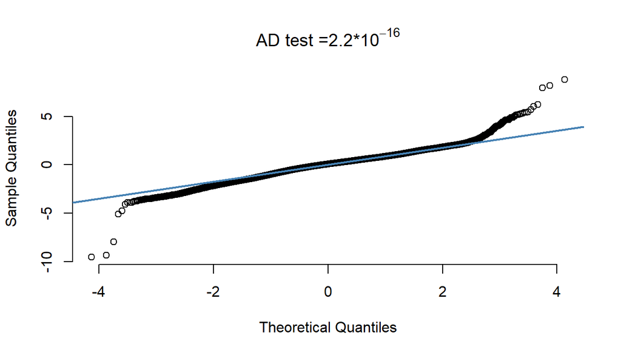

```r
qqnorm(studres(workFinal), pch = 1, frame = FALSE, main=expression("AD test =2.2*10"^-16))
qqline(studres(workFinal), col = "steelblue", lwd = 2)
```

```r
#leverage
lev<-hatvalues(workFinal)
cutlev = (2*length(coefficients(workFinal)))/nrow(workBarcelona)
# Count and assess the number of leverage values > cut-off
potoutlier <- sum(lev > cutlev, na.rm=TRUE)
totcount = length(fitted(workFinal))
print(paste("The number of leverage points that are potential outliers is", potoutlier,".  This is", round(100*potoutlier/totcount,2),"% of the total number of predicted values, (", totcount,") thus not material."))
```

```
## [1] "The number of leverage points that are potential outliers is 1143 .  This is 4.09 % of the total number of predicted values, ( 27962 ) thus not material."
```

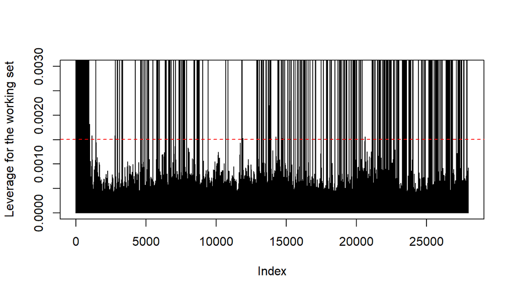

```r
#barplot(lev, ylim = c(0, 2*cutlev))
plot(lev, type="h", ylim = c(0, 2*cutlev), ylab="Leverage for the working set")
abline(h = cutlev, col = "red", lty=2)
```

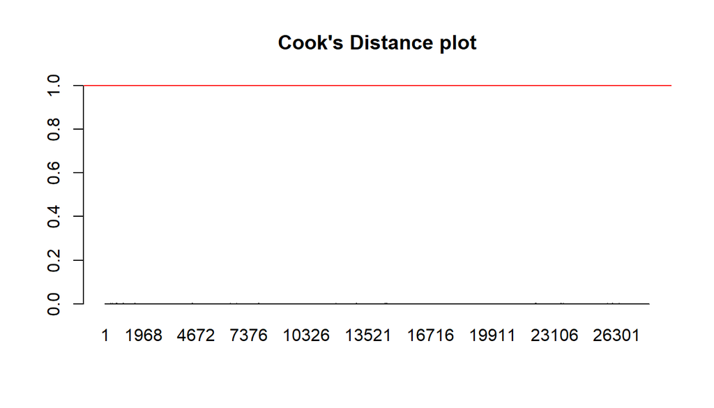

```r
#cook distance
cookdist<-cooks.distance(workFinal)
barplot(cookdist, ylim=c(0,1.01), main = "Cook's Distance plot")
abline(h = 1, col = "red")
```

## Use the estimated model to predict the values in the evaluation set

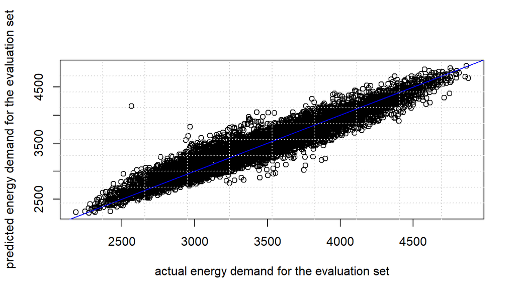

```r
newdata <- evalBarcelona[ c(-2,-13)]
predict.eval <- predict(workFinal, newdata)
plot(x = evalBarcelona$energy_demand, y=predict.eval, xlab="actual energy demand for the evaluation set",
ylab="predicted energy demand for the evaluation set")
abline(a=0, b=1, col="blue")
grid(10,10)
```

## Compute the RMSE for the predictions

```r
rootmse <- rmse(evaldata$energy_demand, predict.eval)
print(paste("The root mean square error of the predicted vs actual",nrow(evaldata),"hourly energy_data points for Barcelona over the 2015-2018 timespan is an energy demand difference of",round(rootmse,2),"kW (assumed unit of measure)."))
```

```
## [1] "The root mean square error of the predicted vs actual 6991 hourly energy_data points for Barcelona over the 2015-2018 timespan is an energy demand difference of 158.46 kW (assumed unit of measure)."
```

```r
cat("\n")
```

```r
diffpct <- c((abs(evaldata$energy_demand - predict.eval))/evaldata$energy_demand)
print(paste("The mean difference between the",nrow(evaldata),"evaluation data set actual and model predicted values is",round(100*mean(diffpct),2),"%."))
```

```
## [1] "The mean difference between the 6991 evaluation data set actual and model predicted values is 3.58 %."
```

## Bilbao Model

```r
evaldata<-read.csv('data\\evaluation_Bilbao.csv')
workdata<-read.csv('data\\working_Bilbao.csv')
#remove index and time_ID columns from "eval" analysis dataframe
evalBilbao<-evaldata[c(-1,-2)]
#remove index and time_ID columns from "work" analysis dataframe
workBilbao<-workdata[c(-1,-2)]
head(workBilbao, 4L)
```

|  | E_1 | E_2 | E_25 | temp | humidity | pressure | wind_speed | rain_duration | snow_duration | day_night | time_band | season | weather_main | energy_demand |
| --- | --- | --- | --- | --- | --- | --- | --- | --- | --- | --- | --- | --- | --- | --- |
| 1 | 926.3269 | 951.3591 | 1061.445 | 270.9400 | 95 | 1036 | 1 | 0 | 0 | 2 | 1 | 4 | 1 | 939.3732 |
| 2 | 1025.7178 | 1085.5091 | 1190.939 | 271.7070 | 95 | 1036 | 1 | 0 | 0 | 1 | 2 | 4 | 1 | 951.3591 |
| 3 | 1085.5091 | 1112.5235 | 1287.426 | 276.8690 | 71 | 1036 | 1 | 0 | 0 | 1 | 3 | 4 | 1 | 1025.7178 |
| 4 | 1112.5235 | 1139.2614 | 1340.210 | 276.5057 | 78 | 1036 | 1 | 0 | 0 | 1 | 3 | 4 | 1 | 1085.5091 |

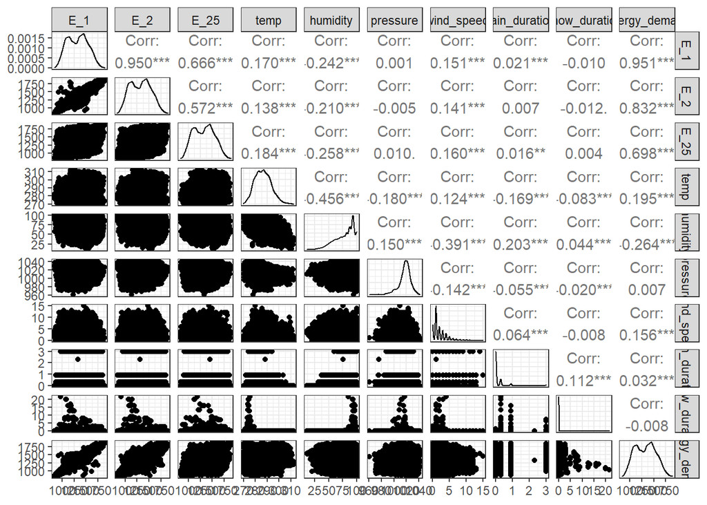

```r
# Correlation matrix for numeric predictors only (categorical predictors excluded)
workcor<-workBilbao[c(-10:-13) ]
ggpairs(workcor)
```

```r
cor(workBilbao)
```

```
##                        E_1          E_2         E_25        temp    humidity
## E_1            1.000000000  0.950416125  0.666120184  0.16975028 -0.24197953
## E_2            0.950416125  1.000000000  0.572366075  0.13813116 -0.20955233
## E_25           0.666120184  0.572366075  1.000000000  0.18402400 -0.25795020
## temp           0.169750281  0.138131159  0.184023995  1.00000000 -0.45578549
## humidity      -0.241979526 -0.209552327 -0.257950204 -0.45578549  1.00000000
## pressure       0.001243665 -0.004772932  0.010307180 -0.17961935  0.14991574
## wind_speed     0.151181867  0.140705953  0.160109653  0.12399994 -0.39111359
## rain_duration  0.021024006  0.006802008  0.015708965 -0.16914530  0.20275768
## snow_duration -0.009655088 -0.011634614  0.004207187 -0.08254669  0.04377467
## day_night     -0.543210750 -0.536657049 -0.510499038 -0.35787009  0.37835040
## time_band      0.111547035  0.091413210  0.108907523 -0.14377910  0.04557368
## season         0.083767426  0.081989974  0.081684368 -0.31709575  0.12271648
## weather_main  -0.040809674 -0.035868875 -0.051582535 -0.23688720  0.36363132
## energy_demand  0.950522266  0.831844301  0.697579126  0.19479147 -0.26418516
##                   pressure   wind_speed rain_duration snow_duration
## E_1            0.001243665  0.151181867   0.021024006  -0.009655088
## E_2           -0.004772932  0.140705953   0.006802008  -0.011634614
## E_25           0.010307180  0.160109653   0.015708965   0.004207187
## temp          -0.179619352  0.123999944  -0.169145298  -0.082546686
## humidity       0.149915737 -0.391113590   0.202757676   0.043774667
## pressure       1.000000000 -0.141997027  -0.054783210  -0.020426827
## wind_speed    -0.141997027  1.000000000   0.063862485  -0.008184950
## rain_duration -0.054783210  0.063862485   1.000000000   0.112363428
## snow_duration -0.020426827 -0.008184950   0.112363428   1.000000000
## day_night      0.030471097 -0.205662072   0.022653559   0.006932406
## time_band      0.044680951 -0.019420697   0.172333309   0.257658930
## season         0.161105330  0.022612319   0.019234862   0.057438676
## weather_main  -0.035694067  0.009074869   0.548511161   0.083538796
## energy_demand  0.007325782  0.156136611   0.031827364  -0.007897999
##                  day_night    time_band      season weather_main energy_demand
## E_1           -0.543210750  0.111547035  0.08376743 -0.040809674   0.950522266
## E_2           -0.536657049  0.091413210  0.08198997 -0.035868875   0.831844301
## E_25          -0.510499038  0.108907523  0.08168437 -0.051582535   0.697579126
## temp          -0.357870091 -0.143779103 -0.31709575 -0.236887201   0.194791472
## humidity       0.378350398  0.045573685  0.12271648  0.363631316  -0.264185164
## pressure       0.030471097  0.044680951  0.16110533 -0.035694067   0.007325782
## wind_speed    -0.205662072 -0.019420697  0.02261232  0.009074869   0.156136611
## rain_duration  0.022653559  0.172333309  0.01923486  0.548511161   0.031827364
## snow_duration  0.006932406  0.257658930  0.05743868  0.083538796  -0.007897999
## day_night      1.000000000  0.000802654  0.14843966  0.041556801  -0.509232928
## time_band      0.000802654  1.000000000  0.16200261  0.072009886   0.122551579
## season         0.148439663  0.162002612  1.00000000  0.041787803   0.084865804
## weather_main   0.041556801  0.072009886  0.04178780  1.000000000  -0.044462642
## energy_demand -0.509232928  0.122551579  0.08486580 -0.044462642   1.000000000
```

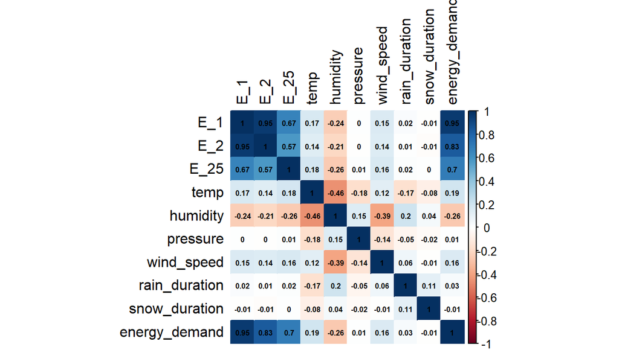

```r
corrplot(cor(workcor), method="color", type="full", addCoef.col = "black", tl.col="black",number.cex = 0.5)
```

## Model Processing

```r
workModelBilbao1 <- lm(energy_demand ~ E_1 + E_2 + E_25 + temp + humidity + pressure + wind_speed + rain_duration + snow_duration + factor(day_night) + factor(time_band) + factor(season) + factor(weather_main), data = workBilbao)
```

```r
vif(workModelBilbao1)
```

```
##                           GVIF Df GVIF^(1/(2*Df))
## E_1                  13.825695  1        3.718292
## E_2                  11.759410  1        3.429200
## E_25                  2.126926  1        1.458399
## temp                  3.015530  1        1.736528
## humidity              2.222049  1        1.490654
## pressure              1.143267  1        1.069237
## wind_speed            1.298526  1        1.139529
## rain_duration         1.714795  1        1.309502
## snow_duration         1.088460  1        1.043293
## factor(day_night)     1.891122  1        1.375181
## factor(time_band)     1.188743  2        1.044172
## factor(season)        2.732502  3        1.182388
## factor(weather_main)  2.237934  8        1.051636
```

```r
workModelBilbaoFull <- lm(energy_demand ~ E_1 + E_25 + temp + humidity + pressure + wind_speed + rain_duration + snow_duration + factor(day_night) + factor(time_band) + factor(season) + factor(weather_main), data = workBilbao)
vif(workModelBilbaoFull)
```

```
##                          GVIF Df GVIF^(1/(2*Df))
## E_1                  2.045408  1        1.430177
## E_25                 1.955972  1        1.398561
## temp                 2.984985  1        1.727711
## humidity             2.220161  1        1.490021
## pressure             1.140561  1        1.067971
## wind_speed           1.297515  1        1.139085
## rain_duration        1.713176  1        1.308884
## snow_duration        1.088426  1        1.043277
## factor(day_night)    1.829662  1        1.352650
## factor(time_band)    1.184551  2        1.043250
## factor(season)       2.715076  3        1.181128
## factor(weather_main) 2.226621  8        1.051303
```

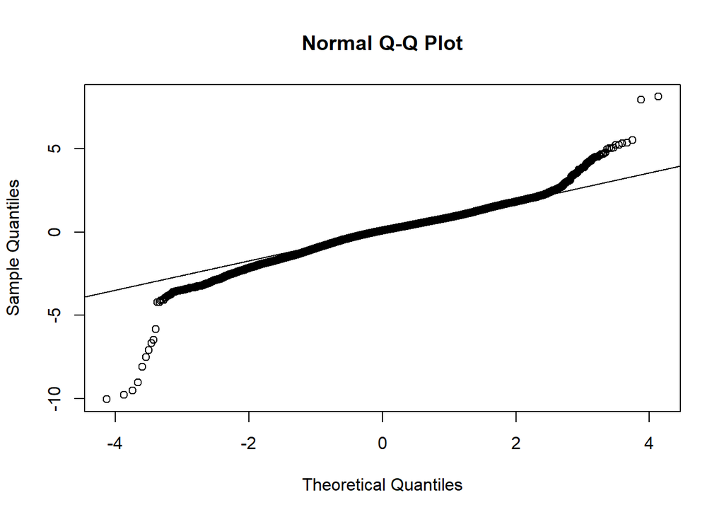

```r
# to obtain residuals
res.fullmodel1 <- residuals(workModelBilbaoFull)
# to obtain standardized residuals
std.res.fullmodel1 <- rstandard(workModelBilbaoFull)
# to obtain fitted/predicted values
pred.fullmodel1 <- fitted.values(workModelBilbaoFull)
par(mfrow=c(1,1))
qqnorm(y = std.res.fullmodel1, main = " Normal Q-Q Plot ",
       xlab = "Theoretical Quantiles", ylab = "Sample Quantiles")
qqline(y = std.res.fullmodel1)
```

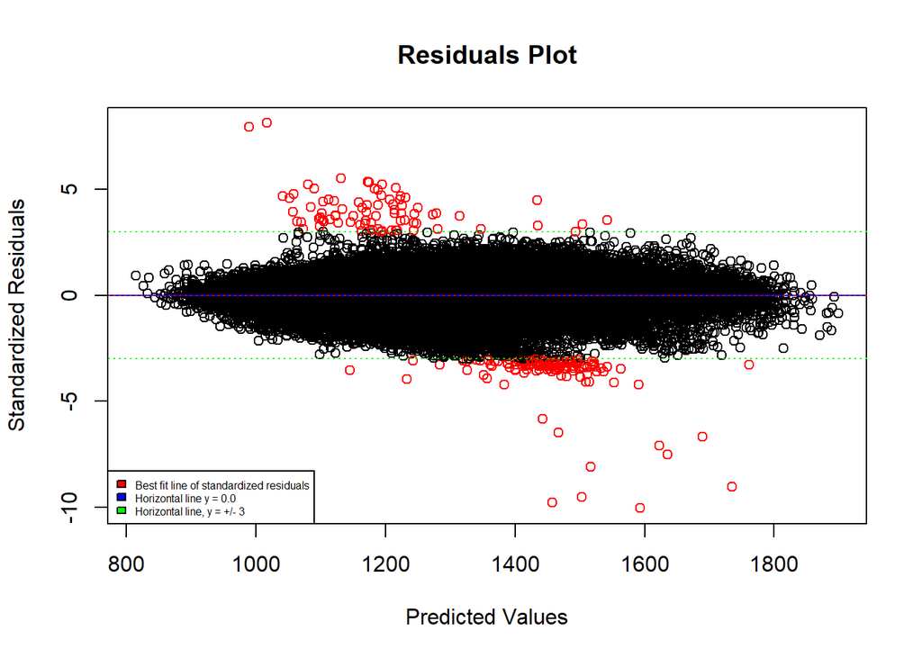

```r
#residual plot
resplotdata1 <- data.frame(std.res.fullmodel1, pred.fullmodel1)
resbf1 <- lm(std.res.fullmodel1 ~ pred.fullmodel1, data = resplotdata1)
plot(x = pred.fullmodel1, y = std.res.fullmodel1, ylab = "Standardized Residuals", xlab = "Predicted Values", main = "Residuals Plot", col = ifelse(std.res.fullmodel1 < -3,"red",ifelse(std.res.fullmodel1 > 3,"red","black")))
abline(h = 0, col="blue", lty=1)
abline(resbf1, col="red", lty=3)
abline(h = 3, col="green", lty=3)
abline(h=-3, col="green", lty=3)
legend("bottomleft", legend=c("Best fit line of standardized residuals", "Horizontal line y = 0.0", "Horizontal line, y = +/- 3"), fill = c("red","blue","green"), cex = 0.5)
```

```r
summary(workModelBilbaoFull)
```

```
##
## Call:
## lm(formula = energy_demand ~ E_1 + E_25 + temp + humidity + pressure +
##     wind_speed + rain_duration + snow_duration + factor(day_night) +
##     factor(time_band) + factor(season) + factor(weather_main),
##     data = workBilbao)
##
## Residuals:
##     Min      1Q  Median      3Q     Max
## -615.23  -34.41    5.87   38.30  498.41
##
## Coefficients:
##                           Estimate  Std. Error t value             Pr(>|t|)
## (Intercept)            -843.345368   49.452318 -17.054 < 0.0000000000000002 ***
## E_1                       0.886138    0.002489 355.972 < 0.0000000000000002 ***
## E_25                      0.118587    0.002430  48.802 < 0.0000000000000002 ***
## temp                      1.711268    0.093774  18.249 < 0.0000000000000002 ***
## humidity                 -0.286970    0.032579  -8.808 < 0.0000000000000002 ***
## pressure                  0.352039    0.039755   8.855 < 0.0000000000000002 ***
## wind_speed               -0.627477    0.224829  -2.791             0.005260 **
## rain_duration             7.690755    1.300967   5.912    0.000000003428051 ***
## snow_duration            -0.492152    0.869973  -0.566             0.571595
## factor(day_night)2       23.551328    0.991964  23.742 < 0.0000000000000002 ***
## factor(time_band)2       -5.058067    5.038289  -1.004             0.315423
## factor(time_band)3       28.792662    3.962867   7.266    0.000000000000381 ***
## factor(season)2         -11.224823    1.322609  -8.487 < 0.0000000000000002 ***
## factor(season)3          -2.110849    1.105037  -1.910             0.056117 .
## factor(season)4           4.222370    1.158219   3.646             0.000267 ***
## factor(weather_main)2     3.794181    0.951709   3.987    0.000067168720903 ***
## factor(weather_main)3    -3.210662    3.844263  -0.835             0.403622
## factor(weather_main)5   -24.366391    2.475180  -9.844 < 0.0000000000000002 ***
## factor(weather_main)6     5.051202    9.076896   0.556             0.577880
## factor(weather_main)7    -5.765315    2.169091  -2.658             0.007866 **
## factor(weather_main)8     6.747903    1.416593   4.763    0.000001912437562 ***
## factor(weather_main)10   11.404431    6.989901   1.632             0.102784
## factor(weather_main)12   28.701904    5.640740   5.088    0.000000363584395 ***
## ---
## Signif. codes:  0 '***' 0.001 '**' 0.01 '*' 0.05 '.' 0.1 ' ' 1
##
## Residual standard error: 61.23 on 27913 degrees of freedom
## Multiple R-squared:  0.9155, Adjusted R-squared:  0.9154
## F-statistic: 1.374e+04 on 22 and 27913 DF,  p-value: < 0.00000000000000022
```

```r
df<- workModelBilbaoFull %>%
  tidy()
#Get the variables which there p-value larger than 0.05
df%>%
  filter(df$p.value>0.05)
```

| term | estimate | std.error | statistic | p.value |
| --- | --- | --- | --- | --- |
| snow_duration | -0.4921524 | 0.8699726 | -0.5657102 | 0.57159531 |
| factor(time_band)2 | -5.0580672 | 5.0382887 | -1.0039256 | 0.31542316 |
| factor(season)3 | -2.1108486 | 1.1050371 | -1.9102060 | 0.05611693 |
| factor(weather_main)3 | -3.2106622 | 3.8442633 | -0.8351827 | 0.40362201 |
| factor(weather_main)6 | 5.0512024 | 9.0768959 | 0.5564901 | 0.57788035 |
| factor(weather_main)10 | 11.4044315 | 6.9899012 | 1.6315583 | 0.10278385 |

```r
workModelBilbaoPvalue <- lm(energy_demand ~ E_1 + E_25 + temp + humidity + pressure + wind_speed + rain_duration + factor(day_night) + factor(time_band) + factor(season) + factor(weather_main), data = workBilbao)
summary(workModelBilbaoPvalue)
```

```
##
## Call:
## lm(formula = energy_demand ~ E_1 + E_25 + temp + humidity + pressure +
##     wind_speed + rain_duration + factor(day_night) + factor(time_band) +
##     factor(season) + factor(weather_main), data = workBilbao)
##
## Residuals:
##     Min      1Q  Median      3Q     Max
## -615.20  -34.39    5.88   38.31  498.47
##
## Coefficients:
##                           Estimate  Std. Error t value             Pr(>|t|)
## (Intercept)            -844.721967   49.391810 -17.102 < 0.0000000000000002 ***
## E_1                       0.886194    0.002487 356.279 < 0.0000000000000002 ***
## E_25                      0.118588    0.002430  48.803 < 0.0000000000000002 ***
## temp                      1.712995    0.093724  18.277 < 0.0000000000000002 ***
## humidity                 -0.286817    0.032578  -8.804 < 0.0000000000000002 ***
## pressure                  0.352826    0.039730   8.881 < 0.0000000000000002 ***
## wind_speed               -0.626634    0.224822  -2.787             0.005319 **
## rain_duration             7.663660    1.300070   5.895    0.000000003794266 ***
## factor(day_night)2       23.566614    0.991584  23.767 < 0.0000000000000002 ***
## factor(time_band)2       -5.472398    4.984709  -1.098             0.272285
## factor(time_band)3       28.328743    3.877040   7.307    0.000000000000281 ***
## factor(season)2         -11.243242    1.322192  -8.503 < 0.0000000000000002 ***
## factor(season)3          -2.118720    1.104936  -1.918             0.055184 .
## factor(season)4           4.211092    1.158034   3.636             0.000277 ***
## factor(weather_main)2     3.791197    0.951683   3.984    0.000068029698640 ***
## factor(weather_main)3    -3.223662    3.844148  -0.839             0.401707
## factor(weather_main)5   -24.367509    2.475149  -9.845 < 0.0000000000000002 ***
## factor(weather_main)6     5.051297    9.076785   0.557             0.577869
## factor(weather_main)7    -5.768356    2.169058  -2.659             0.007833 **
## factor(weather_main)8     6.729794    1.416214   4.752    0.000002024549075 ***
## factor(weather_main)10   11.292661    6.987023   1.616             0.106055
## factor(weather_main)12   28.697055    5.640664   5.088    0.000000365103408 ***
## ---
## Signif. codes:  0 '***' 0.001 '**' 0.01 '*' 0.05 '.' 0.1 ' ' 1
##
## Residual standard error: 61.23 on 27914 degrees of freedom
## Multiple R-squared:  0.9155, Adjusted R-squared:  0.9154
## F-statistic: 1.439e+04 on 21 and 27914 DF,  p-value: < 0.00000000000000022
```

### Reduced model comparisons

- p-value approach

```r
anova(workModelBilbaoPvalue, workModelBilbaoFull)
```

|  | Res.Df | RSS | Df | Sum of Sq | F | Pr(>F) |
| --- | --- | --- | --- | --- | --- | --- |
| 1 | 27914 | 104639673 | NA | NA | NA | NA |
| 2 | 27913 | 104638474 | 1 | 1199.701 | 0.3200281 | 0.5715953 |

- Best subset selection method

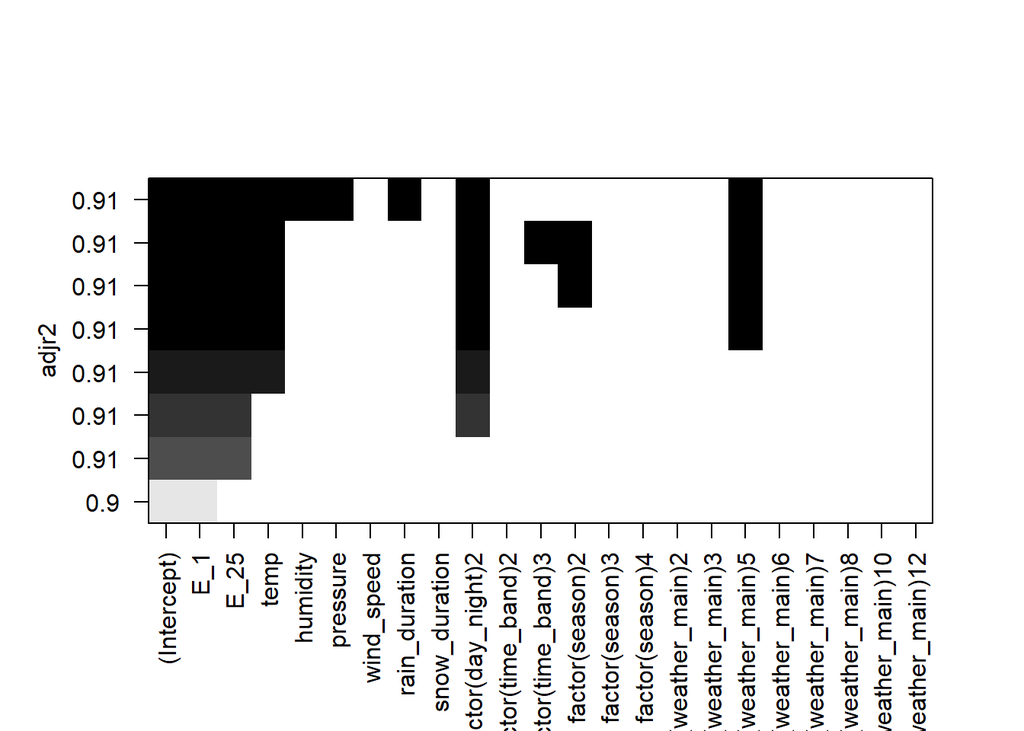

```r
bestfits <- regsubsets(energy_demand ~ E_1 + E_25 + temp + humidity + pressure + wind_speed + rain_duration + snow_duration + factor(day_night) + factor(time_band) + factor(season) + factor(weather_main), data = workBilbao, nbest = 1)
plot(bestfits, scale="adjr2")
```

```r
workModelBilbaoBestfit<-lm(energy_demand ~ E_1 + E_25 + temp + humidity + pressure + rain_duration + factor(day_night) + factor(weather_main), data = workBilbao)
summary(workModelBilbaoBestfit)
```

```
##
## Call:
## lm(formula = energy_demand ~ E_1 + E_25 + temp + humidity + pressure +
##     rain_duration + factor(day_night) + factor(weather_main),
##     data = workBilbao)
##
## Residuals:
##     Min      1Q  Median      3Q     Max
## -617.66  -34.41    6.06   38.16  496.90
##
## Coefficients:
##                           Estimate  Std. Error t value             Pr(>|t|)
## (Intercept)            -695.437687   46.325256 -15.012 < 0.0000000000000002 ***
## E_1                       0.887783    0.002473 358.987 < 0.0000000000000002 ***
## E_25                      0.119907    0.002417  49.614 < 0.0000000000000002 ***
## temp                      1.010725    0.064895  15.575 < 0.0000000000000002 ***
## humidity                 -0.386465    0.027830 -13.886 < 0.0000000000000002 ***
## pressure                  0.404322    0.038946  10.382 < 0.0000000000000002 ***
## rain_duration             8.977057    1.286489   6.978     0.00000000000306 ***
## factor(day_night)2       24.201875    0.975054  24.821 < 0.0000000000000002 ***
## factor(weather_main)2     3.312833    0.939805   3.525             0.000424 ***
## factor(weather_main)3    -3.335437    3.845423  -0.867             0.385742
## factor(weather_main)5   -25.047864    2.477235 -10.111 < 0.0000000000000002 ***
## factor(weather_main)6     5.631042    9.098409   0.619             0.535985
## factor(weather_main)7    -5.766738    2.169447  -2.658             0.007861 **
## factor(weather_main)8     6.706721    1.402354   4.782     0.00000174035237 ***
## factor(weather_main)10   10.135650    6.994897   1.449             0.147347
## factor(weather_main)12   28.485051    5.639427   5.051     0.00000044214473 ***
## ---
## Signif. codes:  0 '***' 0.001 '**' 0.01 '*' 0.05 '.' 0.1 ' ' 1
##
## Residual standard error: 61.41 on 27920 degrees of freedom
## Multiple R-squared:  0.9149, Adjusted R-squared:  0.9149
## F-statistic: 2.002e+04 on 15 and 27920 DF,  p-value: < 0.00000000000000022
```

```r
anova(workModelBilbaoBestfit, workModelBilbaoPvalue)
```

|  | Res.Df | RSS | Df | Sum of Sq | F | Pr(>F) |
| --- | --- | --- | --- | --- | --- | --- |
| 1 | 27920 | 105277219 | NA | NA | NA | NA |
| 2 | 27914 | 104639673 | 6 | 637546 | 28.34562 | 0.0000000000000000000000000000000005549147 |

- AIC with forward selection approach test method

```r
workNullModel<- lm(energy_demand ~ 1, data = workBilbao)
step.working <- stepAIC(workNullModel, scope = list(lower = workNullModel,
upper = workModelBilbaoFull), direction = "forward", trace=FALSE)
summary(step.working)
```

```
##
## Call:
## lm(formula = energy_demand ~ E_1 + E_25 + factor(weather_main) +
##     factor(day_night) + temp + factor(season) + pressure + factor(time_band) +
##     humidity + rain_duration + wind_speed, data = workBilbao)
##
## Residuals:
##     Min      1Q  Median      3Q     Max
## -615.20  -34.39    5.88   38.31  498.47
##
## Coefficients:
##                           Estimate  Std. Error t value             Pr(>|t|)
## (Intercept)            -844.721967   49.391810 -17.102 < 0.0000000000000002 ***
## E_1                       0.886194    0.002487 356.279 < 0.0000000000000002 ***
## E_25                      0.118588    0.002430  48.803 < 0.0000000000000002 ***
## factor(weather_main)2     3.791197    0.951683   3.984    0.000068029698640 ***
## factor(weather_main)3    -3.223662    3.844148  -0.839             0.401707
## factor(weather_main)5   -24.367509    2.475149  -9.845 < 0.0000000000000002 ***
## factor(weather_main)6     5.051297    9.076785   0.557             0.577869
## factor(weather_main)7    -5.768356    2.169058  -2.659             0.007833 **
## factor(weather_main)8     6.729794    1.416214   4.752    0.000002024549075 ***
## factor(weather_main)10   11.292661    6.987023   1.616             0.106055
## factor(weather_main)12   28.697055    5.640664   5.088    0.000000365103408 ***
## factor(day_night)2       23.566614    0.991584  23.767 < 0.0000000000000002 ***
## temp                      1.712995    0.093724  18.277 < 0.0000000000000002 ***
## factor(season)2         -11.243242    1.322192  -8.503 < 0.0000000000000002 ***
## factor(season)3          -2.118720    1.104936  -1.918             0.055184 .
## factor(season)4           4.211092    1.158034   3.636             0.000277 ***
## pressure                  0.352826    0.039730   8.881 < 0.0000000000000002 ***
## factor(time_band)2       -5.472398    4.984709  -1.098             0.272285
## factor(time_band)3       28.328743    3.877040   7.307    0.000000000000281 ***
## humidity                 -0.286817    0.032578  -8.804 < 0.0000000000000002 ***
## rain_duration             7.663660    1.300070   5.895    0.000000003794266 ***
## wind_speed               -0.626634    0.224822  -2.787             0.005319 **
## ---
## Signif. codes:  0 '***' 0.001 '**' 0.01 '*' 0.05 '.' 0.1 ' ' 1
##
## Residual standard error: 61.23 on 27914 degrees of freedom
## Multiple R-squared:  0.9155, Adjusted R-squared:  0.9154
## F-statistic: 1.439e+04 on 21 and 27914 DF,  p-value: < 0.00000000000000022
```

- Cross Validation test method

```r
# Set seed for reproducibility in CV
set.seed(123)
# Set up repeated k-fold cross-validation, with k=10
train.control <- trainControl(method = "cv", number = 10)
# Train the model
step.cv.work <- train(energy_demand ~ E_1 + E_25 + temp + humidity + pressure + wind_speed + rain_duration + snow_duration + factor(day_night) + factor(time_band) + factor(season) + factor(weather_main), data = workBilbao, method = "leapBackward",
tuneGrid = data.frame(nvmax = 1:12),
trControl = train.control)
step.cv.work$results
```

|  | nvmax | RMSE | Rsquared | MAE | RMSESD | RsquaredSD | MAESD |
| --- | --- | --- | --- | --- | --- | --- | --- |
| 1 | 1 | 65.38381 | 0.9034963 | 48.73041 | 0.9647215 | 0.003355347 | 0.6515999 |
| 2 | 2 | 62.80555 | 0.9109386 | 47.74893 | 0.9538856 | 0.003324890 | 0.6794822 |
| 3 | 3 | 62.49293 | 0.9118212 | 47.58592 | 1.0384090 | 0.003490287 | 0.7034686 |
| 4 | 4 | 62.01398 | 0.9131614 | 47.17956 | 1.0900997 | 0.003582851 | 0.7777614 |
| 5 | 5 | 61.84404 | 0.9136354 | 46.99842 | 1.0988693 | 0.003631524 | 0.8073806 |
| 6 | 6 | 61.74182 | 0.9139188 | 46.85490 | 1.1337588 | 0.003717176 | 0.8804563 |
| 7 | 7 | 61.56759 | 0.9144023 | 46.70666 | 1.1374626 | 0.003711984 | 0.9021018 |
| 8 | 8 | 61.46956 | 0.9146738 | 46.61142 | 1.1704353 | 0.003775862 | 0.9074673 |
| 9 | 9 | 61.38853 | 0.9148993 | 46.53135 | 1.1597277 | 0.003769701 | 0.8682640 |
| 10 | 10 | 61.32577 | 0.9150767 | 46.50680 | 1.1359537 | 0.003653276 | 0.8549141 |

[output cut: 2 more lines]

```r
summary(step.cv.work$finalModel)
```

```
## Subset selection object
## 22 Variables  (and intercept)
##                        Forced in Forced out
## E_1                        FALSE      FALSE
## E_25                       FALSE      FALSE
## temp                       FALSE      FALSE
## humidity                   FALSE      FALSE
## pressure                   FALSE      FALSE
## wind_speed                 FALSE      FALSE
## rain_duration              FALSE      FALSE
## snow_duration              FALSE      FALSE
## factor(day_night)2         FALSE      FALSE
## factor(time_band)2         FALSE      FALSE
## factor(time_band)3         FALSE      FALSE
## factor(season)2            FALSE      FALSE
## factor(season)3            FALSE      FALSE
## factor(season)4            FALSE      FALSE
## factor(weather_main)2      FALSE      FALSE
## factor(weather_main)3      FALSE      FALSE
## factor(weather_main)5      FALSE      FALSE
## factor(weather_main)6      FALSE      FALSE
## factor(weather_main)7      FALSE      FALSE
## factor(weather_main)8      FALSE      FALSE
## factor(weather_main)10     FALSE      FALSE
## factor(weather_main)12     FALSE      FALSE
## 1 subsets of each size up to 10
## Selection Algorithm: backward
##           E_1 E_25 temp humidity pressure wind_speed rain_duration
## 1  ( 1 )  "*" " "  " "  " "      " "      " "        " "
## 2  ( 1 )  "*" "*"  " "  " "      " "      " "        " "
## 3  ( 1 )  "*" "*"  " "  " "      " "      " "        " "
## 4  ( 1 )  "*" "*"  "*"  " "      " "      " "        " "
## 5  ( 1 )  "*" "*"  "*"  " "      " "      " "        " "
## 6  ( 1 )  "*" "*"  "*"  "*"      " "      " "        " "
## 7  ( 1 )  "*" "*"  "*"  "*"      " "      " "        "*"
## 8  ( 1 )  "*" "*"  "*"  "*"      "*"      " "        "*"
## 9  ( 1 )  "*" "*"  "*"  "*"      "*"      " "        "*"
## 10  ( 1 ) "*" "*"  "*"  "*"      "*"      " "        "*"
##           snow_duration factor(day_night)2 factor(time_band)2
## 1  ( 1 )  " "           " "                " "
```

[output cut: 38 more lines]

```
## 7  ( 1 )  " "                   " "                   " "
## 8  ( 1 )  " "                   " "                   " "
## 9  ( 1 )  " "                   " "                   " "
## 10  ( 1 ) " "                   " "                   " "
##           factor(weather_main)10 factor(weather_main)12
## 1  ( 1 )  " "                    " "
## 2  ( 1 )  " "                    " "
## 3  ( 1 )  " "                    " "
## 4  ( 1 )  " "                    " "
## 5  ( 1 )  " "                    " "
## 6  ( 1 )  " "                    " "
## 7  ( 1 )  " "                    " "
## 8  ( 1 )  " "                    " "
## 9  ( 1 )  " "                    " "
## 10  ( 1 ) " "                    " "
```

```r
workModelBilbaoCross <- lm(energy_demand ~ E_1 + E_25 + temp + humidity + pressure + rain_duration + factor(day_night) + factor(time_band) + factor(season) + factor(weather_main), data = workBilbao)
anova( workModelBilbaoCross, workModelBilbaoPvalue)
```

|  | Res.Df | RSS | Df | Sum of Sq | F | Pr(>F) |
| --- | --- | --- | --- | --- | --- | --- |
| 1 | 27915 | 104668796 | NA | NA | NA | NA |
| 2 | 27914 | 104639673 | 1 | 29122.3 | 7.768754 | 0.005319361 |

```r
summary(workModelBilbaoCross)
```

```
##
## Call:
## lm(formula = energy_demand ~ E_1 + E_25 + temp + humidity + pressure +
##     rain_duration + factor(day_night) + factor(time_band) + factor(season) +
##     factor(weather_main), data = workBilbao)
##
## Residuals:
##     Min      1Q  Median      3Q     Max
## -614.65  -34.24    5.78   38.30  498.98
##
## Coefficients:
##                           Estimate  Std. Error t value             Pr(>|t|)
## (Intercept)            -858.514226   49.149266 -17.467 < 0.0000000000000002 ***
## E_1                       0.886183    0.002488 356.232 < 0.0000000000000002 ***
## E_25                      0.118493    0.002430  48.763 < 0.0000000000000002 ***
## temp                      1.709718    0.093728  18.241 < 0.0000000000000002 ***
## humidity                 -0.258090    0.030908  -8.350 < 0.0000000000000002 ***
## pressure                  0.364346    0.039520   9.219 < 0.0000000000000002 ***
## rain_duration             7.387297    1.296440   5.698    0.000000012233991 ***
## factor(day_night)2       23.683462    0.990817  23.903 < 0.0000000000000002 ***
## factor(time_band)2       -4.871293    4.980645  -0.978             0.328061
## factor(time_band)3       28.776315    3.874183   7.428    0.000000000000114 ***
## factor(season)2         -11.083574    1.321111  -8.390 < 0.0000000000000002 ***
## factor(season)3          -2.090930    1.105025  -1.892             0.058474 .
## factor(season)4           3.842067    1.150580   3.339             0.000841 ***
## factor(weather_main)2     3.395699    0.941160   3.608             0.000309 ***
## factor(weather_main)3    -3.916569    3.836566  -1.021             0.307333
## factor(weather_main)5   -24.568438    2.474399  -9.929 < 0.0000000000000002 ***
## factor(weather_main)6     4.323982    9.074134   0.477             0.633710
## factor(weather_main)7    -6.100241    2.166050  -2.816             0.004861 **
## factor(weather_main)8     6.238660    1.405379   4.439    0.000009066991407 ***
## factor(weather_main)10   10.962459    6.986866   1.569             0.116657
## factor(weather_main)12   27.670168    5.629302   4.915    0.000000891117747 ***
## ---
## Signif. codes:  0 '***' 0.001 '**' 0.01 '*' 0.05 '.' 0.1 ' ' 1
##
## Residual standard error: 61.23 on 27915 degrees of freedom
## Multiple R-squared:  0.9154, Adjusted R-squared:  0.9154
## F-statistic: 1.511e+04 on 20 and 27915 DF,  p-value: < 0.00000000000000022
```

## Select the final model

Final model is the workModelBilbaoPvalue with highest Adjusted R-square.

### Build the Final Model

```r
workFinal <- lm(energy_demand ~ E_1 + E_25 + temp + humidity + pressure + wind_speed + rain_duration + factor(day_night) + factor(time_band) + factor(season) + factor(weather_main), data = workBilbao)
```

### Check the linearity, heteroscedasticity, outlier and normal assumption

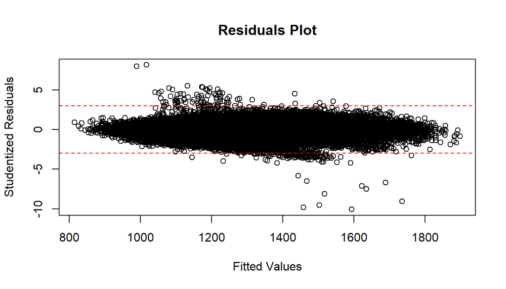

```r
par(mfrow=c(1,1))
#Residual Plot
plot(x=fitted(workFinal), y=studres(workFinal), xlab = "Fitted Values",
ylab = "Studentized Residuals", main='Residuals Plot')
abline(h=-3, col="red", lty=2)
abline(h=3, col="red", lty=2)
```

```r
#norm test
std.res <- rstandard(workFinal)
ad.test(std.res)
```

```
##
##  Anderson-Darling normality test
##
## data:  std.res
## A = 133, p-value < 0.00000000000000022
```

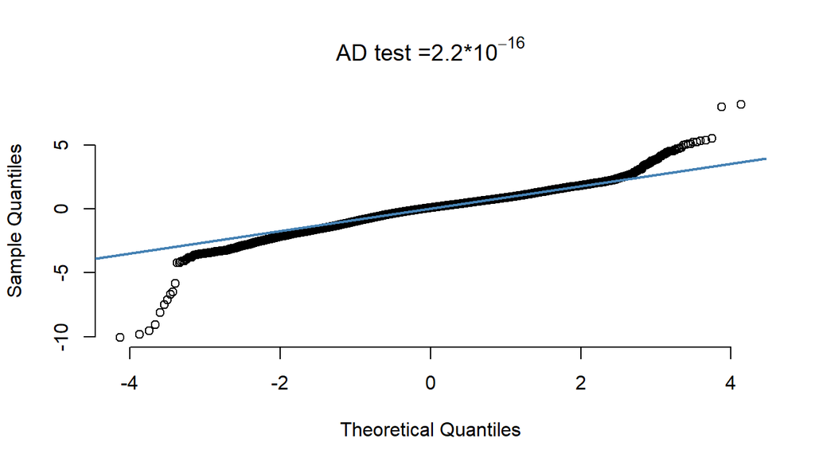

```r
qqnorm(studres(workFinal), pch = 1, frame = FALSE, main=expression("AD test =2.2*10"^-16))
qqline(studres(workFinal), col = "steelblue", lwd = 2)
```

```r
#leverage
lev<-hatvalues(workFinal)
cutlev = (2*length(coefficients(workFinal)))/nrow(workBilbao)
# Count and assess the number of leverage values > cut-off
potoutlier <- sum(lev > cutlev, na.rm=TRUE)
totcount = length(fitted(workFinal))
print(paste("The number of leverage points that are potential outliers is", potoutlier,".  This is", round(100*potoutlier/totcount,2),"% of the total number of predicted values, (", totcount,") thus not material."))
```

```
## [1] "The number of leverage points that are potential outliers is 1860 .  This is 6.66 % of the total number of predicted values, ( 27936 ) thus not material."
```

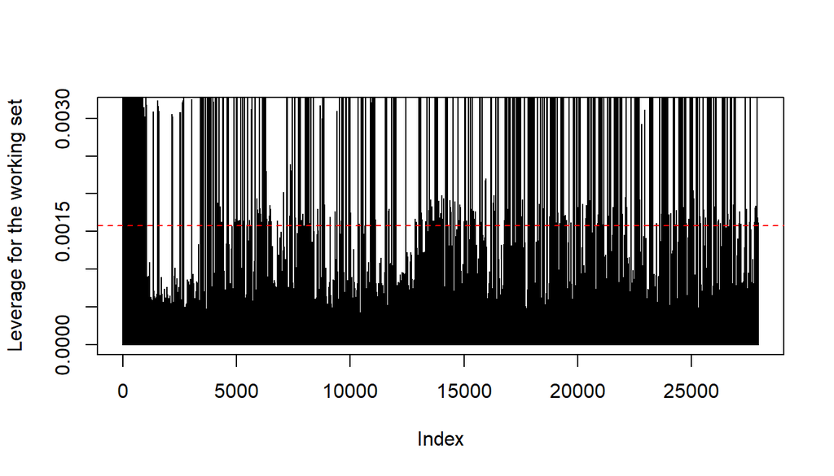

```r
#barplot(lev, ylim = c(0, 2*cutlev))
plot(lev, type="h", ylim = c(0, 2*cutlev), ylab="Leverage for the working set")
abline(h = cutlev, col = "red", lty=2)
```

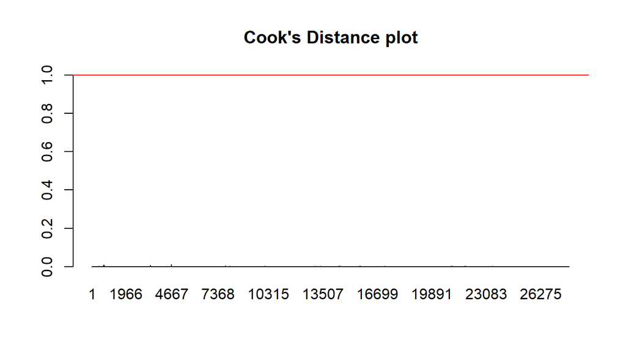

```r
#cook distance
cookdist<-cooks.distance(workFinal)
barplot(cookdist, ylim=c(0,1.01), main = "Cook's Distance plot")
abline(h = 1, col = "red")
```

### Use the estimated model to predict the values in the evaluation set

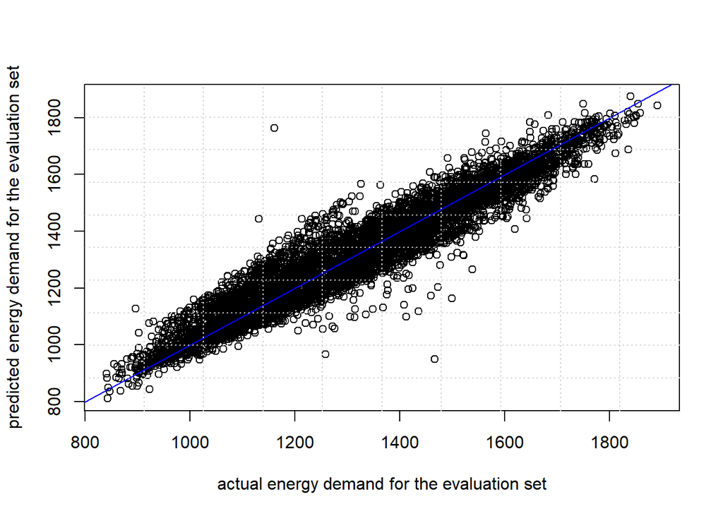

```r
newdata <- evalBilbao[ c(-2,-14)]
predict.eval <- predict(workFinal, newdata)
plot(x = evalBilbao$energy_demand, y=predict.eval, xlab="actual energy demand for the evaluation set",
ylab="predicted energy demand for the evaluation set")
abline(a=0, b=1, col="blue")
grid(10,10)
```

### Compute the RMSE for the predictions

```r
rootmse <- rmse(evalBilbao$energy_demand, predict.eval)
print(paste("The root mean square error of the predicted vs actual",nrow(evaldata),"hourly energy_data points for Bilbao over the 2015-2018 timespan is an energy demand difference of",round(rootmse,2),"kW (assumed unit of measure)."))
```

```
## [1] "The root mean square error of the predicted vs actual 6985 hourly energy_data points for Bilbao over the 2015-2018 timespan is an energy demand difference of 61.98 kW (assumed unit of measure)."
```

```r
diffpct <- c((abs(evalBilbao$energy_demand - predict.eval))/evalBilbao$energy_demand)
print(paste("The mean difference between the",nrow(evalBilbao),"evaluation data set actual and model predicted values is",round(100*mean(diffpct),2),"%."))
```

```
## [1] "The mean difference between the 6985 evaluation data set actual and model predicted values is 3.64 %."
```

## Madrid Model

```r
evaldata<-read.csv('data\\evaluation_Madrid.csv')
workdata<-read.csv('data\\working_Madrid.csv')
#remove index and time_ID columns from "eval" analysis dataframe
evalMadrid<-evaldata[c(-1,-2)]
#remove index and time_ID columns from "work" analysis dataframe
workMadrid<-workdata[c(-1,-2)]
head(workMadrid, 4L)
```

|  | E_1 | E_2 | E_25 | temp | humidity | pressure | wind_speed | rain_duration | snow_duration | day_night | time_band | season | weather_main | energy_demand |
| --- | --- | --- | --- | --- | --- | --- | --- | --- | --- | --- | --- | --- | --- | --- |
| 1 | 1920.228 | 1966.377 | 2132.596 | 281.5740 | 61 | 974 | 1 | 0 | 0 | 1 | 3 | 4 | 1 | 1873.601 |
| 2 | 1963.115 | 1872.089 | 2018.017 | 281.5740 | 61 | 974 | 1 | 0 | 0 | 1 | 3 | 4 | 1 | 1966.377 |
| 3 | 1872.089 | 1839.466 | 1970.913 | 282.5377 | 47 | 1036 | 1 | 0 | 0 | 1 | 2 | 4 | 1 | 1963.115 |
| 4 | 1839.466 | 1878.295 | 1949.509 | 283.3083 | 45 | 1035 | 1 | 0 | 0 | 1 | 2 | 4 | 1 | 1872.089 |

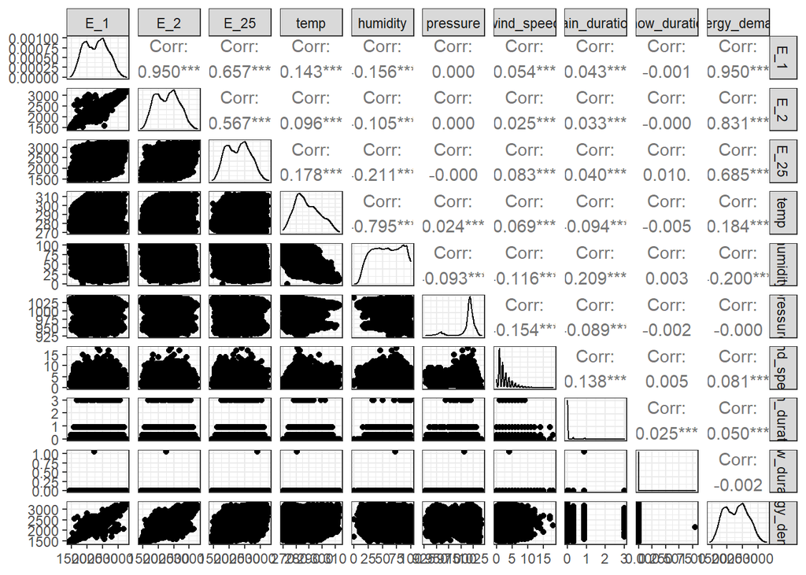

```r
# Correlation matrix for numeric predictors only (categorical predictors excluded)
workcor<-workMadrid[c(-10:-13) ]
ggpairs(workcor)
```

```r
cor(workMadrid)
```

```
##                         E_1           E_2          E_25         temp
## E_1            1.0000000000  0.9499434705  0.6565882882  0.143391210
## E_2            0.9499434705  1.0000000000  0.5667056032  0.095664873
## E_25           0.6565882882  0.5667056032  1.0000000000  0.177936106
## temp           0.1433912096  0.0956648734  0.1779361065  1.000000000
## humidity      -0.1561622663 -0.1045974910 -0.2111986301 -0.794717256
## pressure       0.0004020366  0.0004102668 -0.0003217271  0.023936108
## wind_speed     0.0535245136  0.0249359835  0.0834799950  0.069165992
## rain_duration  0.0430512358  0.0327967771  0.0398224320 -0.094363530
## snow_duration -0.0009123988 -0.0003432574  0.0099683465 -0.005021404
## day_night     -0.5426987515 -0.5357150149 -0.5114772370 -0.310400429
## time_band      0.1141809926  0.0968003546  0.0859565795 -0.125152565
## season         0.0832153797  0.0826213909  0.0824320712 -0.367294486
## weather_main   0.0445935510  0.0373754702  0.0311186482 -0.198277741
## energy_demand  0.9499222286  0.8313872235  0.6847988867  0.184015883
##                   humidity      pressure   wind_speed rain_duration
## E_1           -0.156162266  0.0004020366  0.053524514    0.04305124
## E_2           -0.104597491  0.0004102668  0.024935983    0.03279678
## E_25          -0.211198630 -0.0003217271  0.083479995    0.03982243
## temp          -0.794717256  0.0239361080  0.069165992   -0.09436353
## humidity       1.000000000 -0.0934723236 -0.115914299    0.20892142
## pressure      -0.093472324  1.0000000000 -0.153619309   -0.08927302
## wind_speed    -0.115914299 -0.1536193090  1.000000000    0.13766407
## rain_duration  0.208921418 -0.0892730225  0.137664073    1.00000000
## snow_duration  0.003464459 -0.0018305651  0.004732112    0.02526279
## day_night      0.296478951  0.0108736668 -0.112761329   -0.03948494
## time_band      0.086303385 -0.2942368366  0.045006948    0.00305527
## season         0.316990500  0.0677459079 -0.109874045   -0.05817062
## weather_main   0.384072009 -0.1135259629  0.163858653    0.62217661
## energy_demand -0.200387099 -0.0002102571  0.080783557    0.04958506
##               snow_duration    day_night     time_band       season
## E_1           -0.0009123988 -0.542698752  0.1141809926  0.083215380
## E_2           -0.0003432574 -0.535715015  0.0968003546  0.082621391
## E_25           0.0099683465 -0.511477237  0.0859565795  0.082432071
## temp          -0.0050214038 -0.310400429 -0.1251525653 -0.367294486
## humidity       0.0034644595  0.296478951  0.0863033852  0.316990500
## pressure      -0.0018305651  0.010873667 -0.2942368366  0.067745908
## wind_speed     0.0047321116 -0.112761329  0.0450069477 -0.109874045
## rain_duration  0.0252627940 -0.039484943  0.0030552696 -0.058170615
## snow_duration  1.0000000000 -0.005716835 -0.0007100628 -0.007975021
## day_night     -0.0057168354  1.000000000 -0.0031413686  0.143257400
## time_band     -0.0007100628 -0.003141369  1.0000000000  0.161864278
## season        -0.0079750205  0.143257400  0.1618642784  1.000000000
## weather_main   0.0174843840 -0.044672800  0.0104928162  0.039491421
## energy_demand -0.0021141307 -0.509903410  0.1256833010  0.084139802
##               weather_main energy_demand
## E_1             0.04459355  0.9499222286
## E_2             0.03737547  0.8313872235
## E_25            0.03111865  0.6847988867
## temp           -0.19827774  0.1840158834
## humidity        0.38407201 -0.2003870994
## pressure       -0.11352596 -0.0002102571
## wind_speed      0.16385865  0.0807835573
## rain_duration   0.62217661  0.0495850577
## snow_duration   0.01748438 -0.0021141307
## day_night      -0.04467280 -0.5099034101
## time_band       0.01049282  0.1256833010
## season          0.03949142  0.0841398021
## weather_main    1.00000000  0.0471215127
## energy_demand   0.04712151  1.0000000000
```

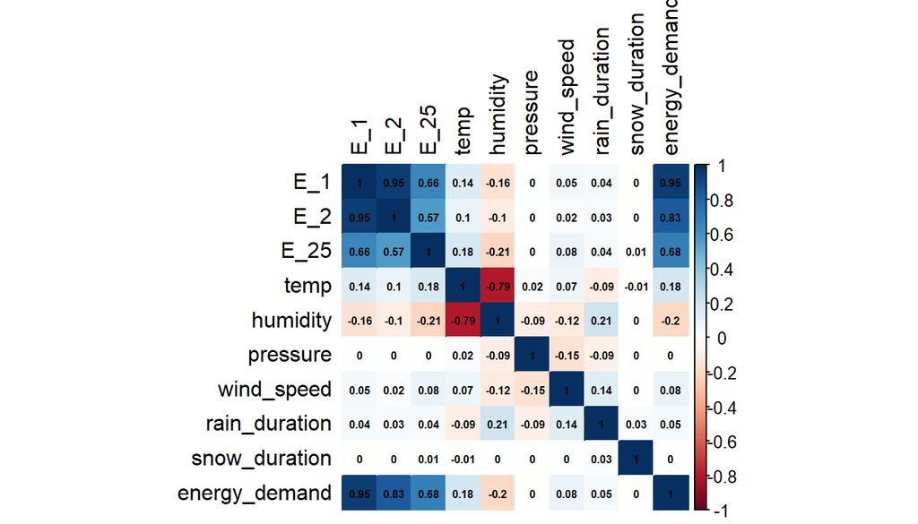

```r
corrplot(cor(workcor), method="color", type="full", addCoef.col = "black", tl.col="black",number.cex = 0.5)
```

```r
workModelMadrid1 <- lm(energy_demand ~ E_1 + E_2 + E_25 + temp + humidity + pressure + wind_speed + rain_duration + snow_duration + factor(day_night) + factor(time_band) + factor(season) + factor(weather_main), data = workMadrid)
```

```r
vif(workModelMadrid1)
```

```
##                           GVIF Df GVIF^(1/(2*Df))
## E_1                  13.683412  1        3.699110
## E_2                  11.842865  1        3.441346
## E_25                  2.066652  1        1.437586
## temp                  4.852956  1        2.202943
## humidity              3.756247  1        1.938104
## pressure              1.202259  1        1.096476
## wind_speed            1.225852  1        1.107182
## rain_duration         2.189530  1        1.479706
## snow_duration         1.001029  1        1.000515
## factor(day_night)     1.806033  1        1.343887
## factor(time_band)     1.206976  2        1.048153
## factor(season)        3.038317  3        1.203480
## factor(weather_main)  3.422558  8        1.079933
```

```r
workModelMadridFull <- lm(energy_demand ~ E_1 + E_25 + temp + humidity + pressure + wind_speed + rain_duration + snow_duration + factor(day_night) + factor(time_band) + factor(season) + factor(weather_main), data = workMadrid)
vif(workModelMadridFull)
```

```
##                          GVIF Df GVIF^(1/(2*Df))
## E_1                  2.004683  1        1.415868
## E_25                 1.935699  1        1.391294
## temp                 4.775330  1        2.185253
## humidity             3.745110  1        1.935229
## pressure             1.201910  1        1.096316
## wind_speed           1.223651  1        1.106187
## rain_duration        2.189374  1        1.479653
## snow_duration        1.001006  1        1.000503
## factor(day_night)    1.732418  1        1.316213
## factor(time_band)    1.202172  2        1.047108
## factor(season)       2.970957  3        1.198991
## factor(weather_main) 3.414880  8        1.079782
```

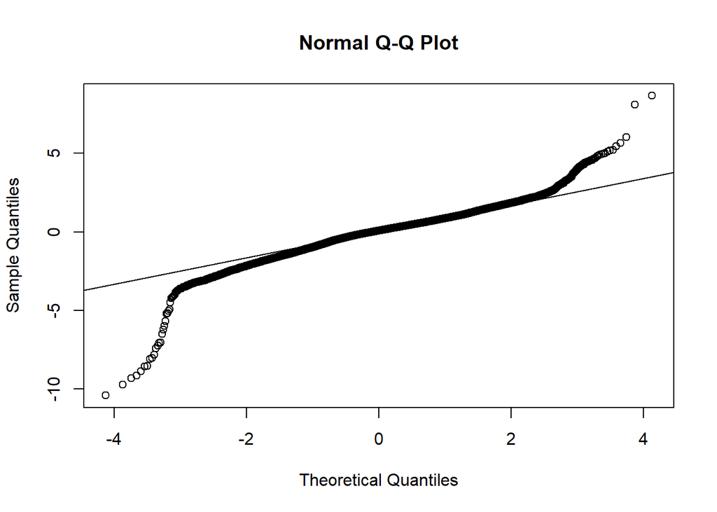

```r
# to obtain residuals
res.fullmodel1 <- residuals(workModelMadridFull)
# to obtain standardized residuals
std.res.fullmodel1 <- rstandard(workModelMadridFull)
# to obtain fitted/predicted values
pred.fullmodel1 <- fitted.values(workModelMadridFull)
par(mfrow=c(1,1))
qqnorm(y = std.res.fullmodel1, main = " Normal Q-Q Plot ",
       xlab = "Theoretical Quantiles", ylab = "Sample Quantiles")
qqline(y = std.res.fullmodel1)
```

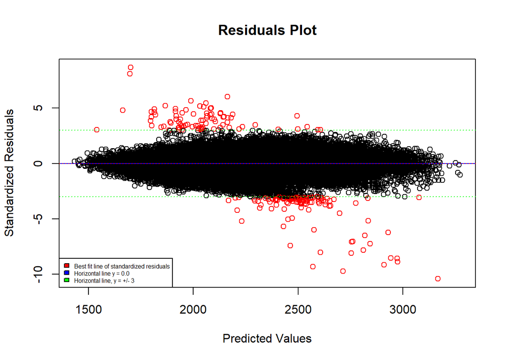

```r
#residual plot
resplotdata1 <- data.frame(std.res.fullmodel1, pred.fullmodel1)
resbf1 <- lm(std.res.fullmodel1 ~ pred.fullmodel1, data = resplotdata1)
plot(x = pred.fullmodel1, y = std.res.fullmodel1, ylab = "Standardized Residuals", xlab = "Predicted Values", main = "Residuals Plot", col = ifelse(std.res.fullmodel1 < -3,"red",ifelse(std.res.fullmodel1 > 3,"red","black")))
abline(h = 0, col="blue", lty=1)
abline(resbf1, col="red", lty=3)
abline(h = 3, col="green", lty=3)
abline(h=-3, col="green", lty=3)
legend("bottomleft", legend=c("Best fit line of standardized residuals", "Horizontal line y = 0.0", "Horizontal line, y = +/- 3"), fill = c("red","blue","green"), cex = 0.5)
```

```r
summary(workModelMadridFull)
```

```
##
## Call:
## lm(formula = energy_demand ~ E_1 + E_25 + temp + humidity + pressure +
##     wind_speed + rain_duration + snow_duration + factor(day_night) +
##     factor(time_band) + factor(season) + factor(weather_main),
##     data = workMadrid)
##
## Residuals:
##      Min       1Q   Median       3Q      Max
## -1097.14   -56.10     9.01    63.40   914.40
##
## Coefficients:
##                            Estimate   Std. Error t value             Pr(>|t|)
## (Intercept)            -1093.188294    59.986245 -18.224 < 0.0000000000000002
## E_1                        0.892155     0.002464 362.140 < 0.0000000000000002
## E_25                       0.103032     0.002424  42.513 < 0.0000000000000002
## temp                       3.432903     0.150672  22.784 < 0.0000000000000002
## humidity                  -0.563259     0.049087 -11.475 < 0.0000000000000002
## pressure                   0.121147     0.034840   3.477             0.000507
## wind_speed                 2.491848     0.355546   7.009     0.00000000000246
## rain_duration             13.671539     4.609904   2.966             0.003023
## snow_duration           -124.613076   100.661587  -1.238             0.215749
## factor(day_night)2        42.023414     1.669358  25.173 < 0.0000000000000002
## factor(time_band)2         8.612174     8.811459   0.977             0.328388
## factor(time_band)3        74.552399     6.956330  10.717 < 0.0000000000000002
## factor(season)2          -48.870952     2.298821 -21.259 < 0.0000000000000002
## factor(season)3           -7.374987     1.870953  -3.942     0.00008105907428
## factor(season)4           25.722059     2.070951  12.420 < 0.0000000000000002
## factor(weather_main)2      8.527549     1.568031   5.438     0.00000005422072
## factor(weather_main)3     14.908620     6.279141   2.374             0.017589
## factor(weather_main)5      4.942025     5.673912   0.871             0.383757
## factor(weather_main)6     -7.593469    27.311364  -0.278             0.780989
## factor(weather_main)7     18.121717     5.063404   3.579             0.000346
## factor(weather_main)8     27.082310     3.935399   6.882     0.00000000000604
## factor(weather_main)10    40.922832    18.759636   2.181             0.029160
## factor(weather_main)12    32.889632     9.415102   3.493             0.000478
##
## (Intercept)            ***
## E_1                    ***
## E_25                   ***
```

[output cut: 11 more lines]

```
## factor(season)4        ***
## factor(weather_main)2  ***
## factor(weather_main)3  *
## factor(weather_main)5
## factor(weather_main)6
## factor(weather_main)7  ***
## factor(weather_main)8  ***
## factor(weather_main)10 *
## factor(weather_main)12 ***
## ---
## Signif. codes:  0 '***' 0.001 '**' 0.01 '*' 0.05 '.' 0.1 ' ' 1
##
## Residual standard error: 105.5 on 27740 degrees of freedom
## Multiple R-squared:  0.9161, Adjusted R-squared:  0.916
## F-statistic: 1.377e+04 on 22 and 27740 DF,  p-value: < 0.00000000000000022
```

```r
df<- workModelMadridFull %>%
  tidy()
#Get the variables which there p-value larger than 0.05
df%>%
  filter(df$p.value>0.05)
```

| term | estimate | std.error | statistic | p.value |
| --- | --- | --- | --- | --- |
| snow_duration | -124.613076 | 100.661587 | -1.2379407 | 0.2157485 |
| factor(time_band)2 | 8.612174 | 8.811459 | 0.9773835 | 0.3283879 |
| factor(weather_main)5 | 4.942025 | 5.673912 | 0.8710084 | 0.3837571 |
| factor(weather_main)6 | -7.593469 | 27.311364 | -0.2780333 | 0.7809889 |

```r
workModelMadridPvalue <- lm(energy_demand ~ E_1 + E_25 + temp + humidity + pressure + wind_speed + rain_duration + factor(day_night) + factor(time_band) + factor(season) + factor(weather_main), data = workMadrid)
summary(workModelMadridPvalue)
```

```
##
## Call:
## lm(formula = energy_demand ~ E_1 + E_25 + temp + humidity + pressure +
##     wind_speed + rain_duration + factor(day_night) + factor(time_band) +
##     factor(season) + factor(weather_main), data = workMadrid)
##
## Residuals:
##      Min       1Q   Median       3Q      Max
## -1097.12   -56.13     9.00    63.40   914.46
##
## Coefficients:
##                            Estimate   Std. Error t value             Pr(>|t|)
## (Intercept)            -1093.581173    59.985981 -18.231 < 0.0000000000000002
## E_1                        0.892186     0.002463 362.168 < 0.0000000000000002
## E_25                       0.102993     0.002423  42.500 < 0.0000000000000002
## temp                       3.434373     0.150669  22.794 < 0.0000000000000002
## humidity                  -0.562954     0.049087 -11.468 < 0.0000000000000002
## pressure                   0.121104     0.034840   3.476             0.000510
## wind_speed                 2.492271     0.355549   7.010     0.00000000000244
## rain_duration             13.595711     4.609541   2.949             0.003186
## factor(day_night)2        42.030231     1.669365  25.177 < 0.0000000000000002
## factor(time_band)2         8.614108     8.811544   0.978             0.328284
## factor(time_band)3        74.551969     6.956397  10.717 < 0.0000000000000002
## factor(season)2          -48.869024     2.298842 -21.258 < 0.0000000000000002
## factor(season)3           -7.363501     1.870948  -3.936     0.00008315458019
## factor(season)4           25.742089     2.070908  12.430 < 0.0000000000000002
## factor(weather_main)2      8.525961     1.568045   5.437     0.00000005454471
## factor(weather_main)3     14.917369     6.279198   2.376             0.017523
## factor(weather_main)5      4.936703     5.673965   0.870             0.384274
## factor(weather_main)6     -7.601158    27.311626  -0.278             0.780775
## factor(weather_main)7     18.113599     5.063448   3.577             0.000348
## factor(weather_main)8     27.056170     3.935380   6.875     0.00000000000633
## factor(weather_main)10    40.938710    18.759812   2.182             0.029099
## factor(weather_main)12    32.907720     9.415181   3.495             0.000474
##
## (Intercept)            ***
## E_1                    ***
## E_25                   ***
## temp                   ***
## humidity               ***
```

[output cut: 8 more lines]

```
## factor(season)4        ***
## factor(weather_main)2  ***
## factor(weather_main)3  *
## factor(weather_main)5
## factor(weather_main)6
## factor(weather_main)7  ***
## factor(weather_main)8  ***
## factor(weather_main)10 *
## factor(weather_main)12 ***
## ---
## Signif. codes:  0 '***' 0.001 '**' 0.01 '*' 0.05 '.' 0.1 ' ' 1
##
## Residual standard error: 105.5 on 27741 degrees of freedom
## Multiple R-squared:  0.9161, Adjusted R-squared:  0.916
## F-statistic: 1.442e+04 on 21 and 27741 DF,  p-value: < 0.00000000000000022
```

- p-value approach

```r
anova(workModelMadridPvalue, workModelMadridFull)
```

|  | Res.Df | RSS | Df | Sum of Sq | F | Pr(>F) |
| --- | --- | --- | --- | --- | --- | --- |
| 1 | 27741 | 308998752 | NA | NA | NA | NA |
| 2 | 27740 | 308981682 | 1 | 17069.7 | 1.532497 | 0.2157485 |

- Best subset selection method

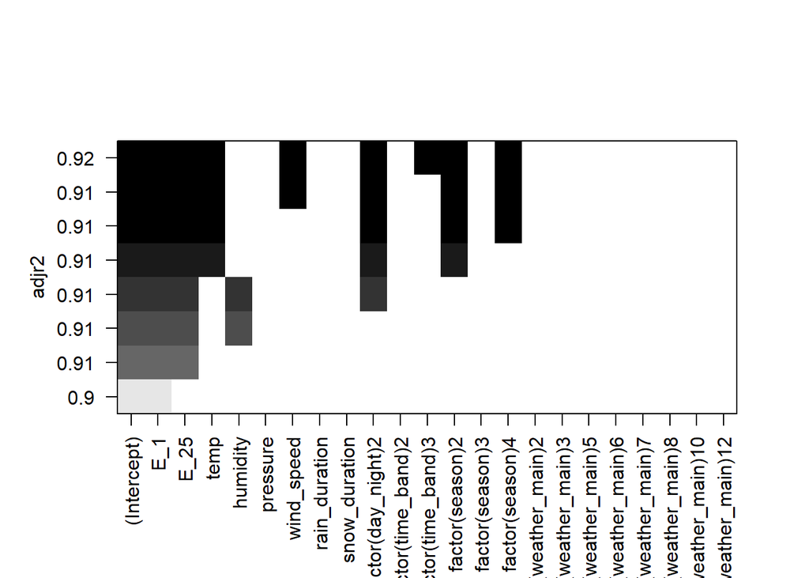

```r
bestfits <- regsubsets(energy_demand ~ E_1 + E_25 + temp + humidity + pressure + wind_speed + rain_duration + snow_duration + factor(day_night) + factor(time_band) + factor(season) + factor(weather_main), data = workMadrid, nbest = 1)
plot(bestfits, scale="adjr2")
```

```r
workModelMadridBestfit<-lm(energy_demand ~ E_1 + E_25 + temp + wind_speed + factor(day_night) + factor(time_band) + factor(season) , data = workMadrid)
summary(workModelMadridBestfit)
```

```
##
## Call:
## lm(formula = energy_demand ~ E_1 + E_25 + temp + wind_speed +
##     factor(day_night) + factor(time_band) + factor(season), data = workMadrid)
##
## Residuals:
##      Min       1Q   Median       3Q      Max
## -1084.09   -56.96     9.10    64.09   916.61
##
## Coefficients:
##                        Estimate   Std. Error t value             Pr(>|t|)
## (Intercept)        -1293.374957    32.392614 -39.928 < 0.0000000000000002 ***
## E_1                    0.892776     0.002471 361.305 < 0.0000000000000002 ***
## E_25                   0.106053     0.002420  43.822 < 0.0000000000000002 ***
## temp                   4.427351     0.112498  39.355 < 0.0000000000000002 ***
## wind_speed             3.789287     0.332289  11.404 < 0.0000000000000002 ***
## factor(day_night)2    40.399494     1.662907  24.294 < 0.0000000000000002 ***
## factor(time_band)2     1.913481     8.661304   0.221                0.825
## factor(time_band)3    67.719513     6.725624  10.069 < 0.0000000000000002 ***
## factor(season)2      -52.144538     2.274335 -22.927 < 0.0000000000000002 ***
## factor(season)3       -9.819047     1.859339  -5.281          0.000000129 ***
## factor(season)4       23.902070     2.030660  11.771 < 0.0000000000000002 ***
## ---
## Signif. codes:  0 '***' 0.001 '**' 0.01 '*' 0.05 '.' 0.1 ' ' 1
##
## Residual standard error: 106 on 27752 degrees of freedom
## Multiple R-squared:  0.9154, Adjusted R-squared:  0.9154
## F-statistic: 3.002e+04 on 10 and 27752 DF,  p-value: < 0.00000000000000022
```

```r
anova(workModelMadridBestfit, workModelMadridPvalue)
```

|  | Res.Df | RSS | Df | Sum of Sq | F | Pr(>F) |
| --- | --- | --- | --- | --- | --- | --- |
| 1 | 27752 | 311591757 | NA | NA | NA | NA |
| 2 | 27741 | 308998752 | 11 | 2593005 | 21.16294 | 0.0000000000000000000000000000000000000000001736169 |

- AIC with forward selection approach test method

```r
workNullModel<- lm(energy_demand ~ 1, data = workMadrid)
step.working <- stepAIC(workNullModel, scope = list(lower = workNullModel,
upper = workModelMadridFull), direction = "forward", trace=FALSE)
summary(step.working)
```

```
##
## Call:
## lm(formula = energy_demand ~ E_1 + E_25 + humidity + factor(day_night) +
##     factor(weather_main) + factor(season) + temp + factor(time_band) +
##     wind_speed + pressure + rain_duration, data = workMadrid)
##
## Residuals:
##      Min       1Q   Median       3Q      Max
## -1097.12   -56.13     9.00    63.40   914.46
##
## Coefficients:
##                            Estimate   Std. Error t value             Pr(>|t|)
## (Intercept)            -1093.581173    59.985981 -18.231 < 0.0000000000000002
## E_1                        0.892186     0.002463 362.168 < 0.0000000000000002
## E_25                       0.102993     0.002423  42.500 < 0.0000000000000002
## humidity                  -0.562954     0.049087 -11.468 < 0.0000000000000002
## factor(day_night)2        42.030231     1.669365  25.177 < 0.0000000000000002
## factor(weather_main)2      8.525961     1.568045   5.437     0.00000005454471
## factor(weather_main)3     14.917369     6.279198   2.376             0.017523
## factor(weather_main)5      4.936703     5.673965   0.870             0.384274
## factor(weather_main)6     -7.601158    27.311626  -0.278             0.780775
## factor(weather_main)7     18.113599     5.063448   3.577             0.000348
## factor(weather_main)8     27.056170     3.935380   6.875     0.00000000000633
## factor(weather_main)10    40.938710    18.759812   2.182             0.029099
## factor(weather_main)12    32.907720     9.415181   3.495             0.000474
## factor(season)2          -48.869024     2.298842 -21.258 < 0.0000000000000002
## factor(season)3           -7.363501     1.870948  -3.936     0.00008315458019
## factor(season)4           25.742089     2.070908  12.430 < 0.0000000000000002
## temp                       3.434373     0.150669  22.794 < 0.0000000000000002
## factor(time_band)2         8.614108     8.811544   0.978             0.328284
## factor(time_band)3        74.551969     6.956397  10.717 < 0.0000000000000002
## wind_speed                 2.492271     0.355549   7.010     0.00000000000244
## pressure                   0.121104     0.034840   3.476             0.000510
## rain_duration             13.595711     4.609541   2.949             0.003186
##
## (Intercept)            ***
## E_1                    ***
## E_25                   ***
## humidity               ***
## factor(day_night)2     ***
```

[output cut: 8 more lines]

```
## factor(season)2        ***
## factor(season)3        ***
## factor(season)4        ***
## temp                   ***
## factor(time_band)2
## factor(time_band)3     ***
## wind_speed             ***
## pressure               ***
## rain_duration          **
## ---
## Signif. codes:  0 '***' 0.001 '**' 0.01 '*' 0.05 '.' 0.1 ' ' 1
##
## Residual standard error: 105.5 on 27741 degrees of freedom
## Multiple R-squared:  0.9161, Adjusted R-squared:  0.916
## F-statistic: 1.442e+04 on 21 and 27741 DF,  p-value: < 0.00000000000000022
```

- Cross Validation test method

```r
# Set seed for reproducibility in CV
set.seed(123)
# Set up repeated k-fold cross-validation, with k=10
train.control <- trainControl(method = "cv", number = 10)
# Train the model
step.cv.work <- train(energy_demand ~ E_1 + E_25 + temp + humidity + pressure + wind_speed + rain_duration + snow_duration + factor(day_night) + factor(time_band) + factor(season) + factor(weather_main), data = workMadrid, method = "leapBackward",
tuneGrid = data.frame(nvmax = 1:12),
trControl = train.control)
```

```
## Reordering variables and trying again:
```

```r
step.cv.work$results
```

|  | nvmax | RMSE | Rsquared | MAE | RMSESD | RsquaredSD | MAESD |
| --- | --- | --- | --- | --- | --- | --- | --- |
| 1 | 1 | 113.8012 | 0.9023457 | 84.30824 | 1.948347 | 0.004389500 | 0.9893949 |
| 2 | 2 | 109.9230 | 0.9088964 | 82.74661 | 1.625471 | 0.003601595 | 0.7364565 |
| 3 | 3 | 108.9859 | 0.9104468 | 81.93727 | 1.726894 | 0.003674432 | 0.8672170 |
| 4 | 4 | 108.2161 | 0.9117083 | 81.46060 | 1.768056 | 0.003709915 | 0.9710545 |
| 5 | 5 | 107.3859 | 0.9130643 | 80.63998 | 1.761923 | 0.003627885 | 0.9083121 |
| 6 | 6 | 106.8527 | 0.9139215 | 80.09162 | 1.952032 | 0.003824981 | 1.1075716 |
| 7 | 7 | 106.7235 | 0.9141312 | 79.93302 | 1.996313 | 0.003868924 | 1.1255361 |
| 8 | 8 | 106.4179 | 0.9146221 | 79.66371 | 2.058379 | 0.003905021 | 1.1880056 |
| 9 | 9 | 106.2091 | 0.9149600 | 79.51340 | 1.964473 | 0.003787775 | 1.0442886 |
| 10 | 10 | 106.0067 | 0.9152803 | 79.32306 | 2.011997 | 0.003855203 | 1.0494644 |

[output cut: 2 more lines]

```r
summary(step.cv.work$finalModel)
```

```
## Subset selection object
## 22 Variables  (and intercept)
##                        Forced in Forced out
## E_1                        FALSE      FALSE
## E_25                       FALSE      FALSE
## temp                       FALSE      FALSE
## humidity                   FALSE      FALSE
## pressure                   FALSE      FALSE
## wind_speed                 FALSE      FALSE
## rain_duration              FALSE      FALSE
## snow_duration              FALSE      FALSE
## factor(day_night)2         FALSE      FALSE
## factor(time_band)2         FALSE      FALSE
## factor(time_band)3         FALSE      FALSE
## factor(season)2            FALSE      FALSE
```

[output cut: 90 more lines]

```r
workModelMadridCross <- lm(energy_demand ~ E_1 + E_25 + temp + humidity + wind_speed + rain_duration + factor(day_night) + factor(time_band) + factor(season) + factor(weather_main), data = workMadrid)
anova( workModelMadridCross, workModelMadridPvalue)
```

|  | Res.Df | RSS | Df | Sum of Sq | F | Pr(>F) |
| --- | --- | --- | --- | --- | --- | --- |
| 1 | 27742 | 309133337 | NA | NA | NA | NA |
| 2 | 27741 | 308998752 | 1 | 134585.5 | 12.08269 | 0.0005096993 |

```r
summary(workModelMadridCross)
```

```
##
## Call:
## lm(formula = energy_demand ~ E_1 + E_25 + temp + humidity + wind_speed +
##     rain_duration + factor(day_night) + factor(time_band) + factor(season) +
##     factor(weather_main), data = workMadrid)
##
## Residuals:
##      Min       1Q   Median       3Q      Max
## -1097.70   -56.04     8.94    63.55   915.46
##
## Coefficients:
##                           Estimate  Std. Error t value             Pr(>|t|)
## (Intercept)            -957.033754   45.343201 -21.106 < 0.0000000000000002 ***
## E_1                       0.892368    0.002463 362.251 < 0.0000000000000002 ***
## E_25                      0.102965    0.002424  42.480 < 0.0000000000000002 ***
## temp                      3.389425    0.150143  22.575 < 0.0000000000000002 ***
## humidity                 -0.583777    0.048730 -11.980 < 0.0000000000000002 ***
## wind_speed                2.360256    0.353585   6.675      0.0000000000252 ***
## rain_duration            14.273068    4.606340   3.099             0.001947 **
## factor(day_night)2       42.044434    1.669693  25.181 < 0.0000000000000002 ***
## factor(time_band)2        2.621027    8.642947   0.303             0.761697
## factor(time_band)3       68.228323    6.715646  10.160 < 0.0000000000000002 ***
## factor(season)2         -48.456952    2.296242 -21.103 < 0.0000000000000002 ***
## factor(season)3          -6.874955    1.866034  -3.684             0.000230 ***
## factor(season)4          26.410474    2.062374  12.806 < 0.0000000000000002 ***
## factor(weather_main)2     8.205598    1.565647   5.241      0.0000001608532 ***
## factor(weather_main)3    14.948023    6.280446   2.380             0.017315 *
## factor(weather_main)5     6.066888    5.665773   1.071             0.284270
## factor(weather_main)6    -7.420466   27.317031  -0.272             0.785899
## factor(weather_main)7    19.151012    5.055654   3.788             0.000152 ***
## factor(weather_main)8    25.713836    3.917169   6.564      0.0000000000532 ***
## factor(weather_main)10   40.421348   18.762968   2.154             0.031224 *
## factor(weather_main)12   33.431946    9.415854   3.551             0.000385 ***
## ---
## Signif. codes:  0 '***' 0.001 '**' 0.01 '*' 0.05 '.' 0.1 ' ' 1
##
## Residual standard error: 105.6 on 27742 degrees of freedom
## Multiple R-squared:  0.9161, Adjusted R-squared:  0.916
## F-statistic: 1.514e+04 on 20 and 27742 DF,  p-value: < 0.00000000000000022
```

## Select the final model

Model adjusted R-square from above methods

1. P-value: 0.916
2. Bestfits: 0.9154
3. AIC Method: 0.916
4. Cross-validation: 0.916

### Build the Final Model

```r
workFinal <- workModelMadridCross
```

### Check the linearity, heteroscedasticity, outlier and normal assumption

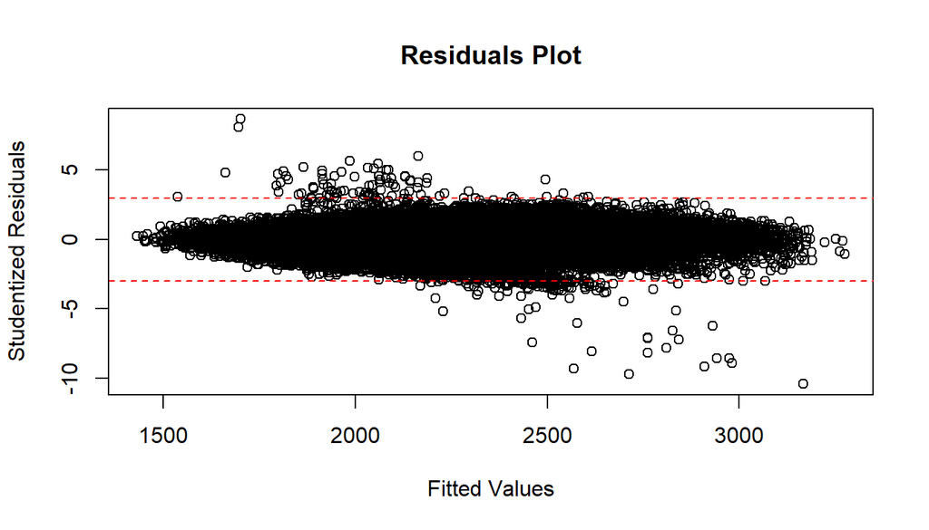

```r
par(mfrow=c(1,1))
#Residual Plot
plot(x=fitted(workFinal), y=studres(workFinal), xlab = "Fitted Values",
ylab = "Studentized Residuals", main='Residuals Plot')
abline(h=-3, col="red", lty=2)
abline(h=3, col="red", lty=2)
```

```r
#norm test
std.res <- rstandard(workFinal)
ad.test(std.res)
```

```
##
##  Anderson-Darling normality test
##
## data:  std.res
## A = 148.07, p-value < 0.00000000000000022
```

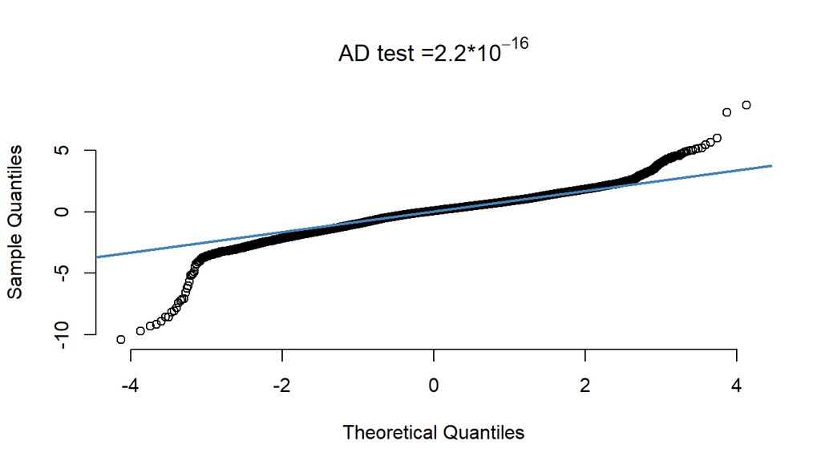

```r
qqnorm(studres(workFinal), pch = 1, frame = FALSE, main=expression("AD test =2.2*10"^-16))
qqline(studres(workFinal), col = "steelblue", lwd = 2)
```

```r
#leverage
lev<-hatvalues(workFinal)
cutlev = (2*length(coefficients(workFinal)))/nrow(workMadrid)
# Count and assess the number of leverage values > cut-off
potoutlier <- sum(lev > cutlev, na.rm=TRUE)
totcount = length(fitted(workFinal))
print(paste("The number of leverage points that are potential outliers is", potoutlier,".  This is", round(100*potoutlier/totcount,2),"% of the total number of predicted values, (", totcount,") thus not material."))
```

```
## [1] "The number of leverage points that are potential outliers is 1871 .  This is 6.74 % of the total number of predicted values, ( 27763 ) thus not material."
```

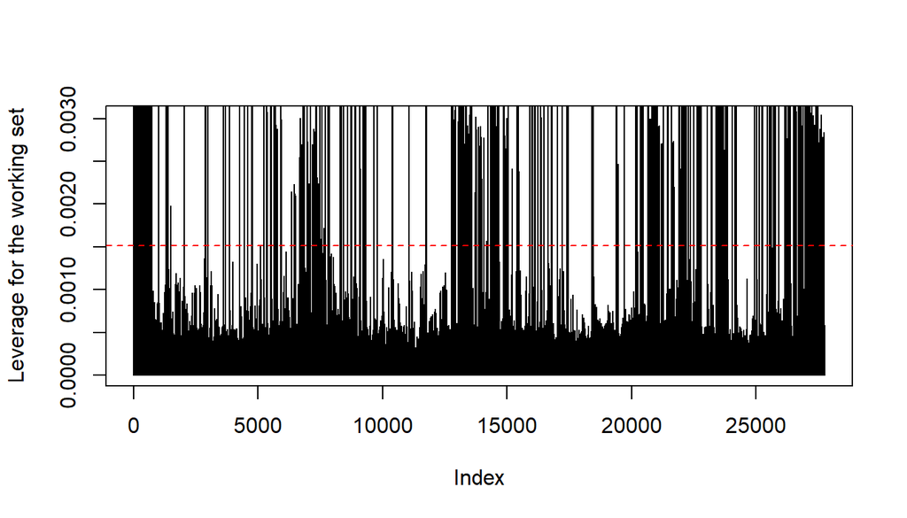

```r
#barplot(lev, ylim = c(0, 2*cutlev))
plot(lev, type="h", ylim = c(0, 2*cutlev), ylab="Leverage for the working set")
abline(h = cutlev, col = "red", lty=2)
```

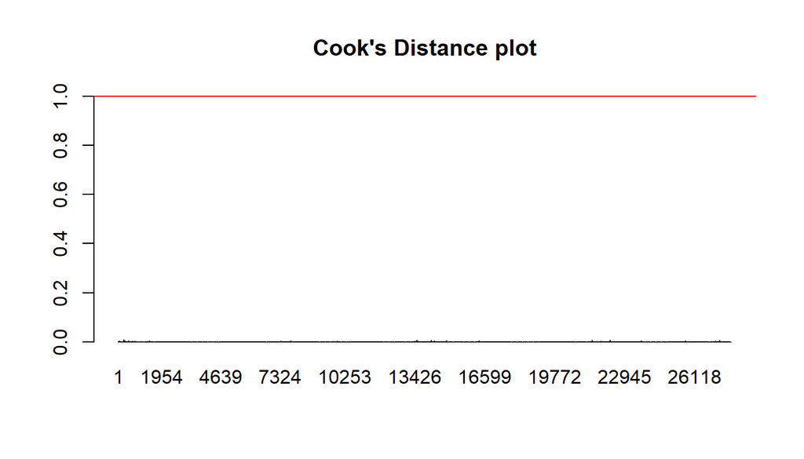

```r
#cook distance
cookdist<-cooks.distance(workFinal)
barplot(cookdist, ylim=c(0,1.01), main = "Cook's Distance plot")
abline(h = 1, col = "red")
```

### Use the estimated model to predict the values in the evaluation set

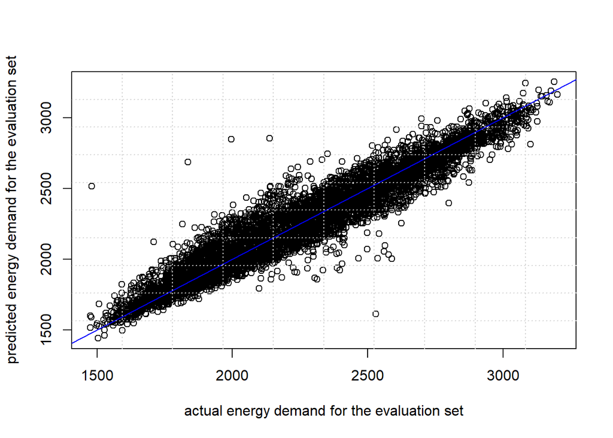

```r
newdata <- evalMadrid[ c(-2,-14)]
predict.eval <- predict(workFinal, newdata)
plot(x = evalMadrid$energy_demand, y=predict.eval, xlab="actual energy demand for the evaluation set",
ylab="predicted energy demand for the evaluation set")
abline(a=0, b=1, col="blue")
grid(10,10)
```

### Compute the RMSE for the predictions

```r
rootmse <- rmse(evalMadrid$energy_demand, predict.eval)
print(paste("The root mean square error of the predicted vs actual",nrow(evaldata),"hourly energy_data points for Madrid over the 2015-2018 timespan is an energy demand difference of",round(rootmse,2),"kW (assumed unit of measure)."))
```

```
## [1] "The root mean square error of the predicted vs actual 6941 hourly energy_data points for Madrid over the 2015-2018 timespan is an energy demand difference of 107.09 kW (assumed unit of measure)."
```

```r
diffpct <- c((abs(evalMadrid$energy_demand - predict.eval))/evalMadrid$energy_demand)
print(paste("The mean difference between the",nrow(evalMadrid),"evaluation data set actual and model predicted values is",round(100*mean(diffpct),2),"%."))
```

```
## [1] "The mean difference between the 6941 evaluation data set actual and model predicted values is 3.57 %."
```

## Seville Model

```r
evaldata<-read.csv('data\\evaluation_Seville.csv')
workdata<-read.csv('data\\working_Seville.csv')
#remove index, time_ID and snow_duration columns from "eval" analysis dataframe
evalSeville<-evaldata[c(-1,-2,-11)]
#remove index, time_ID and snow_duration columns from "work" analysis dataframe
workSeville<-workdata[c(-1,-2,-11)]
head(workSeville, 4L)
```

|  | E_1 | E_2 | E_25 | temp | humidity | pressure | wind_speed | rain_duration | day_night | time_band | season | weather_main | energy_demand |
| --- | --- | --- | --- | --- | --- | --- | --- | --- | --- | --- | --- | --- | --- |
| 1 | 1025.7701 | 956.4375 | 1138.8564 | 273.375 | 75 | 1039 | 1 | 0 | 2 | 1 | 4 | 1 | 1067.9671 |
| 2 | 895.5189 | 852.5226 | 976.6314 | 274.086 | 71 | 1039 | 3 | 0 | 2 | 1 | 4 | 1 | 956.4375 |
| 3 | 852.5226 | 837.4192 | 948.2757 | 274.086 | 71 | 1039 | 3 | 0 | 2 | 1 | 4 | 1 | 895.5189 |
| 4 | 837.4192 | 841.8366 | 929.5963 | 274.086 | 71 | 1039 | 3 | 0 | 2 | 1 | 4 | 1 | 852.5226 |

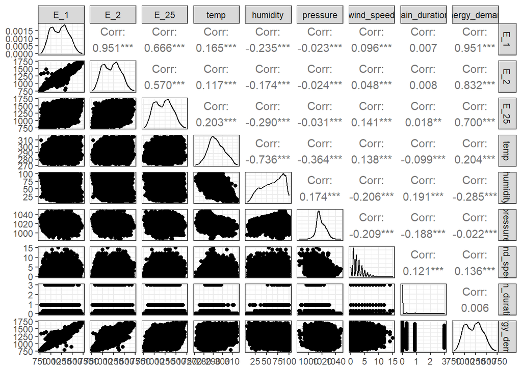

```r
# Correlation matrix for numeric predictors only (categorical predictors excluded)
workcor<-workSeville[c(-9:-12) ]
ggpairs(workcor)
```

```r
cor(workSeville)
```

```
##                        E_1          E_2        E_25        temp    humidity
## E_1            1.000000000  0.950854151  0.66638363  0.16537305 -0.23468751
## E_2            0.950854151  1.000000000  0.57019030  0.11747631 -0.17392319
## E_25           0.666383630  0.570190303  1.00000000  0.20343503 -0.28989939
## temp           0.165373052  0.117476309  0.20343503  1.00000000 -0.73635552
## humidity      -0.234687511 -0.173923187 -0.28989939 -0.73635552  1.00000000
## pressure      -0.023117084 -0.023737213 -0.03106706 -0.36378957  0.17368694
## wind_speed     0.096162157  0.048258690  0.14126341  0.13787943 -0.20591888
## rain_duration  0.007157484  0.007868531  0.01752647 -0.09919377  0.19053553
## day_night     -0.542317356 -0.534651817 -0.51052068 -0.36647493  0.39007951
## time_band      0.111533226  0.091257807  0.11285140 -0.14760780  0.08535442
## season         0.080795009  0.080745711  0.07745398 -0.36184280  0.25243795
## weather_main  -0.004452486  0.011227066 -0.02136187 -0.19715308  0.35226130
## energy_demand  0.950980801  0.832402107  0.69960726  0.20376123 -0.28491923
##                  pressure  wind_speed rain_duration    day_night    time_band
## E_1           -0.02311708  0.09616216   0.007157484 -0.542317356  0.111533226
## E_2           -0.02373721  0.04825869   0.007868531 -0.534651817  0.091257807
## E_25          -0.03106706  0.14126341   0.017526469 -0.510520679  0.112851400
## temp          -0.36378957  0.13787943  -0.099193770 -0.366474926 -0.147607803
## humidity       0.17368694 -0.20591888   0.190535534  0.390079509  0.085354419
## pressure       1.00000000 -0.20855776  -0.187508867  0.068019733  0.188780617
## wind_speed    -0.20855776  1.00000000   0.121015082 -0.175701943  0.056228332
## rain_duration -0.18750887  0.12101508   1.000000000 -0.009750599  0.000193738
## day_night      0.06801973 -0.17570194  -0.009750599  1.000000000  0.001903622
## time_band      0.18878062  0.05622833   0.000193738  0.001903622  1.000000000
## season         0.41474625 -0.08705692  -0.046310357  0.151516388  0.163866226
## weather_main  -0.16600812  0.09555784   0.572527418  0.025237816  0.006401385
## energy_demand -0.02150207  0.13592024   0.006346723 -0.509531109  0.123373405
##                    season weather_main energy_demand
## E_1            0.08079501 -0.004452486   0.950980801
## E_2            0.08074571  0.011227066   0.832402107
## E_25           0.07745398 -0.021361874   0.699607258
## temp          -0.36184280 -0.197153079   0.203761230
## humidity       0.25243795  0.352261299  -0.284919235
## pressure       0.41474625 -0.166008124  -0.021502073
## wind_speed    -0.08705692  0.095557837   0.135920236
## rain_duration -0.04631036  0.572527418   0.006346723
## day_night      0.15151639  0.025237816  -0.509531109
## time_band      0.16386623  0.006401385   0.123373405
## season         1.00000000  0.024505939   0.080486767
## weather_main   0.02450594  1.000000000  -0.022175596
## energy_demand  0.08048677 -0.022175596   1.000000000
```

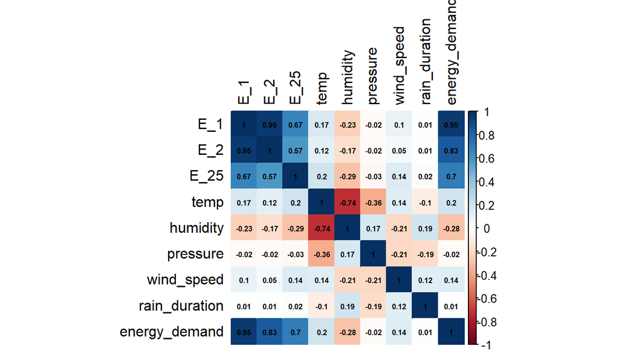

```r
corrplot(cor(workcor), method="color", type="full", addCoef.col = "black", tl.col="black",number.cex = 0.5)
```